# Bioinformatic analysis

2023-03-16

Abstract:

The COVID-19 disease is caused by the SARS-CoV-2 virus and is responsible for one of the worst pandemics in modern history. HIV is a virus that destroys the immune system and makes the body vulnerable to infections and diseases. Previous studies show that HIV-infected individuals are at a higher risk of severe COVID-19 outcomes and mortality. However, the scientific community still lacks knowledge about how COVID-19 and HIV interact at the molecular level. Our goal was to investigate the blood transcriptome interaction (crosstalk) between COVID-19 and HIV, in order to provide an initial basis to potential treatments for HIV-infected COVID-19 patients. We performed gene expression analysis using “Deseq2” and “limma” to identify differentially expressed genes (DEG) in each of the two conditions. Then we intersected the results to obtain the common DEG. The intersection yielded 436 significant (adj. P-value < 0.05) genes in COVID-19 & HIV vs. healthy patients. Afterwards, we used “GSEA” from “clusterProfiler” package, to find hallmarks pathways for common DEG. The enrichment analysis indicated that common DEGs were mainly gathered in cell cycle-related signal pathways. A very meaningful outcome in our analysis was top ten hub genes (PLK1, RRM2, FOXM1, MKI67, RAD54L, BUB1B, RAD51, SPC25, SDC1, HMGA1) which were ranked according to their scores. In the second analysis we ran survival analysis (TCGA) on the first COVID-19 dataset. Using clusters of significant gene groups we observed differences in the final survival plot. We’ll mention that instead of referring the mortality state, we treated patients under severe or ICU condition as dead (hence performing ICU risk analysis). Our findings provide potential molecular targets, signaling pathways and promising biomarkers that contribute to worse COVID-19 prognosis in patients with HIV. All of the above might aid to precise diagnosis and treatment for HIV-infected COVID-19 patients, as we aspire. (296 <3)

### Differential gene expression analysis with with DESeq2 For The covid datasets

- Set Working directory and packages (We set here just some of the packages as we encountered dependencies problems which affected the plots we created)

```r
setwd('C:/Users/Ofer/OneDrive - Technion/Documents/236523/final')
library(GEOquery, quietly = T)
library(tidyverse, quietly = T)
library(DESeq2, quietly = T)
```

## We’ll begin with the first dataset accession number - GSE152418 (dataset 1)

* We are basing our project on an article we found: https://www.frontiersin.org/articles/10.3389/fimmu.2022.1008653/full

The first out of the two COVID-19 datasets used in the article appeared to be the same as we used in Tutorial 4. Hence, we also use it as a “reference” point for the DESeq analysis of the second dataset, which is constructed a bit different. We want to replicate the article results, where the DEG analysis of the COVID-19 datasets were also done with this method/tool.

- Read data into R

```r
counts <- read_table("GSE152418_p20047_Study1_RawCounts.txt.gz")
gse <- getGEO(filename="GSE152418_series_matrix.txt")
```

- Take a look at the gene counts data

```r
head(counts)
```

```
## # A tibble: 6 × 35
##   ENSEMBLID      S145_…¹ S147_…² S149_…³ S150_…⁴ S151_…⁵ S152_…⁶ S153_…⁷ S154_…⁸
##   <chr>            <dbl>   <dbl>   <dbl>   <dbl>   <dbl>   <dbl>   <dbl>   <dbl>
## 1 ENSG000002239…       0       0       0       0       0       0       0       0
## 2 ENSG000002272…       1       0       3      16       1       2      18       6
## 3 ENSG000002782…       3       1       2       0       3       0       0       1
## 4 ENSG000002434…       2       0       0       1       0       0       0       0
## 5 ENSG000002843…       0       0       0       0       0       0       0       0
## 6 ENSG000002376…       0       0       0       0       0       0       0       0
## # … with 26 more variables: S155_nCOV021EUHM <dbl>,
## #   `S156_nCOV024EUHM-Draw-1` <dbl>, S157_nCOV0029EUHM <dbl>,
## #   `S175_nCoV024EUHM-Draw-2` <dbl>, `S176_nCoV025EUHM-Draw-1` <dbl>,
## #   `S177_nCoV025EUHM-Draw-2` <dbl>, `S178_nCoV028EUHM-Draw-1` <dbl>,
## #   `S179_nCoV033EUHM-Draw-1` <dbl>, `S180_nCoV034EUHM-Draw-1` <dbl>,
## #   S061_257 <dbl>, S062_258 <dbl>, S063_259 <dbl>, S064_260 <dbl>,
## #   S065_261 <dbl>, S066_265 <dbl>, S067_270 <dbl>, S068_272 <dbl>, …
```

We can see it is the same format we used in the tutorial. Cols == Samples, Rows == Gene ENSEMBLE coding.

- Read the metadata

```r
metadata <- as_tibble(gse)
head(metadata)
```

```
## # A tibble: 6 × 50
##   title     geo_a…¹ status submi…² last_…³ type  chann…⁴ sourc…⁵ organ…⁶ chara…⁷
##   <chr>     <chr>   <chr>  <chr>   <chr>   <chr> <chr>   <chr>   <chr>   <chr>
## 1 S145_nCO… GSM461… Publi… Jun 13… Feb 01… SRA   1       PBMC    Homo s… days_p…
## 2 S147_nCo… GSM461… Publi… Jun 13… Feb 01… SRA   1       PBMC    Homo s… days_p…
## 3 S149_nCo… GSM461… Publi… Jun 13… Feb 01… SRA   1       PBMC    Homo s… days_p…
## 4 S150_nCo… GSM461… Publi… Jun 13… Feb 01… SRA   1       PBMC    Homo s… days_p…
## 5 S151_nCo… GSM461… Publi… Jun 13… Feb 01… SRA   1       PBMC    Homo s… days_p…
## 6 S152_nCo… GSM461… Publi… Jun 13… Feb 01… SRA   1       PBMC    Homo s… days_p…
## # … with 40 more variables: characteristics_ch1.1 <chr>,
## #   characteristics_ch1.2 <chr>, characteristics_ch1.3 <chr>,
## #   characteristics_ch1.4 <chr>, characteristics_ch1.5 <chr>,
## #   molecule_ch1 <chr>, extract_protocol_ch1 <chr>,
## #   extract_protocol_ch1.1 <chr>, taxid_ch1 <chr>, data_processing <chr>,
## #   data_processing.1 <chr>, data_processing.2 <chr>, data_processing.3 <chr>,
## #   data_processing.4 <chr>, platform_id <chr>, contact_name <chr>, …
```

- Select relevant column in metadata

```r
metadata <- metadata %>%
  dplyr::select(sample = title, disease = disease.state.ch1, gender = gender.ch1, severity = severity.ch1)
head(metadata)
```

```
## # A tibble: 6 × 4
##   sample                  disease      gender severity
##   <chr>                   <chr>        <chr>  <chr>
## 1 S145_nCOV001_C          Convalescent M      Convalescent
## 2 S147_nCoV001EUHM-Draw-1 COVID-19     F      Moderate
## 3 S149_nCoV002EUHM-Draw-2 COVID-19     M      Severe
## 4 S150_nCoV003EUHM-Draw-1 COVID-19     F      Severe
## 5 S151_nCoV004EUHM-Draw-1 COVID-19     M      ICU
## 6 S152_nCoV006EUHM-Draw-1 COVID-19     M      Severe
```

- Remove “Convalescent” sample

```r
table(metadata$disease)
```

```
##
## Convalescent     COVID-19      Healthy
##            1           16           17
```

```r
metadata <- metadata %>%
  filter(disease != "Convalescent")

table(metadata$disease)
```

```
##
## COVID-19  Healthy
##       16       17
```

- Make sure the counts matrix corresponds to the metadata

```r
counts <- cbind(ENSEMBLID = counts$ENSEMBLID, counts[,metadata$sample])
all(metadata$sample == colnames(counts)[-1])
```

```
## [1] TRUE
```

- Set disease state as a factor

```r
class(metadata$disease)
```

```
## [1] "character"
```

```r
metadata <- mutate(metadata, disease = as.factor(disease))
class(metadata$disease)
```

```
## [1] "factor"
```

```r
head(metadata$disease)
```

```
## [1] COVID-19 COVID-19 COVID-19 COVID-19 COVID-19 COVID-19
## Levels: COVID-19 Healthy
```

# Now we are ready for Differential Expression Analysis!

- Constructs a DESeq2 object

```r
dds <- DESeqDataSetFromMatrix(countData=counts,
                              colData=metadata,
                              design= ~disease,
                              tidy=TRUE)
```

```
##   Note: levels of factors in the design contain characters other than
##   letters, numbers, '_' and '.'. It is recommended (but not required) to use
##   only letters, numbers, and delimiters '_' or '.', as these are safe characters
##   for column names in R. [This is a message, not a warning or an error]
```

- Next we run DESeq2 from start to end in a single command

```r
dds <- DESeq(dds)
```

[output not shown]

[output not shown]

[output not shown]

[output not shown]

```
## -- replacing outliers and refitting for 151 genes
## -- DESeq argument 'minReplicatesForReplace' = 7
## -- original counts are preserved in counts(dds)
```

[output not shown]

[output not shown]

| We’ll next look at the gene-wise dispersion and the distribution of gene |
| --- |
| expression, to show the similarity of the two datasets regarding the problems |
| we saw in class. |
| As the visual analysis is similar we justify the usage of the same solutions. |
| i.e. using the negative binomial distribution. |

Estimate gene-wise dispersion - We need a reliable measure of variability for each gene between biological replicates (batch effect). - Dispersion estimates and reflects the variance in gene expression for a given mean value.

(PROBLEM RECAP) (a) With only a few replicates per group, the estimates of variation for each gene is often unreliable (b) For genes with low mean counts the variance have much larger spread

```r
dds <- estimateDispersions(dds)
```

```
## found already estimated dispersions, replacing these
```

[output not shown]

[output not shown]

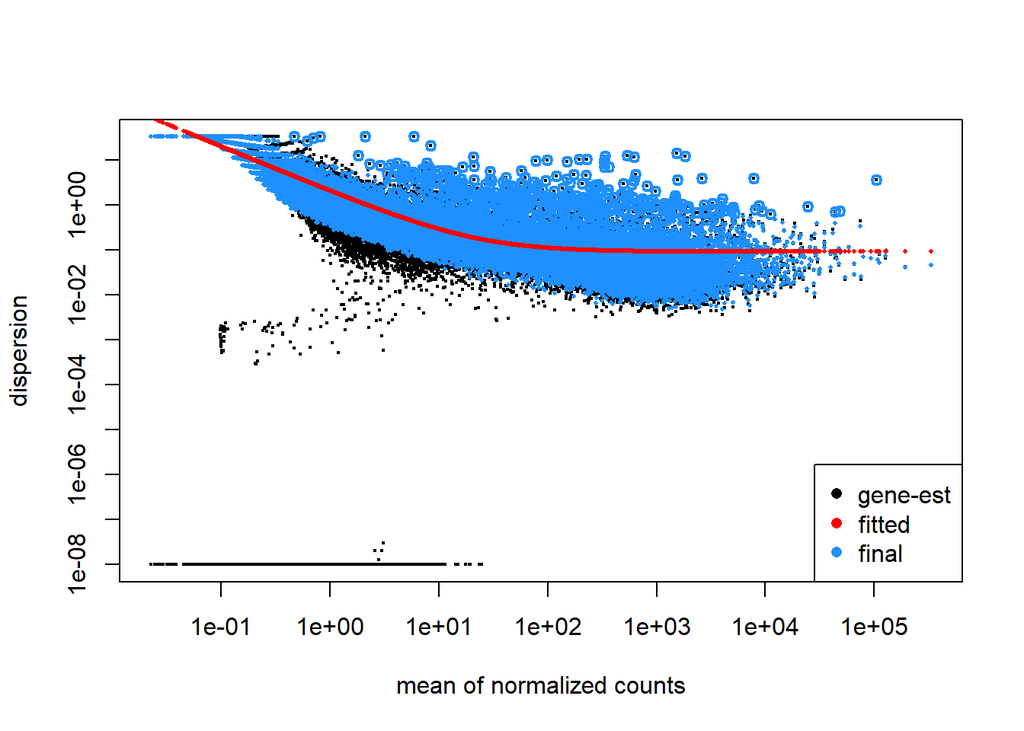

```r
plotDispEsts(dds)
```

Negative Binomial distribution and Wald statistics

(PROBLEM RECAP) (C) We don’t get a uniform distribution, hence we can’t use the t-test, and we should find alternative distribution and test.

- The distribution of gene expression

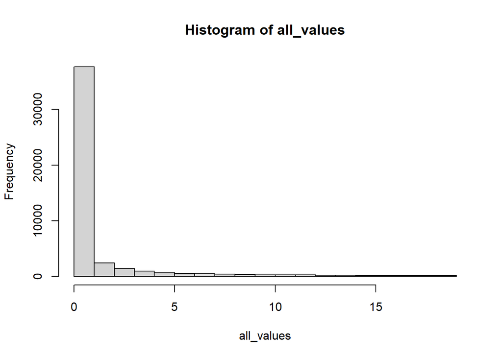

```r
all_values <- pull(counts[,-1])
all_values <- all_values[all_values<20]
hist(all_values, breaks = 20)
```

- Solution: Negative binomial distribution, Wald test

```r
dds <- nbinomWaldTest(dds)
```

- Getting differential expression results:

```r
res <- results(dds)
mcols(res, use.names=T)
```

```
## DataFrame with 6 rows and 2 columns
##                        type            description
##                 <character>            <character>
## baseMean       intermediate mean of normalized c..
## log2FoldChange      results log2 fold change (ML..
## lfcSE               results standard error: dise..
## stat                results Wald statistic: dise..
## pvalue              results Wald test p-value: d..
## padj                results   BH adjusted p-values
```

```r
summary(res)
```

```
##
## out of 53704 with nonzero total read count
## adjusted p-value < 0.1
## LFC > 0 (up)       : 3806, 7.1%
## LFC < 0 (down)     : 8330, 16%
## outliers [1]       : 148, 0.28%
## low counts [2]     : 20682, 39%
## (mean count < 0)
## [1] see 'cooksCutoff' argument of ?results
## [2] see 'independentFiltering' argument of ?results
```

- distribution of p-values:

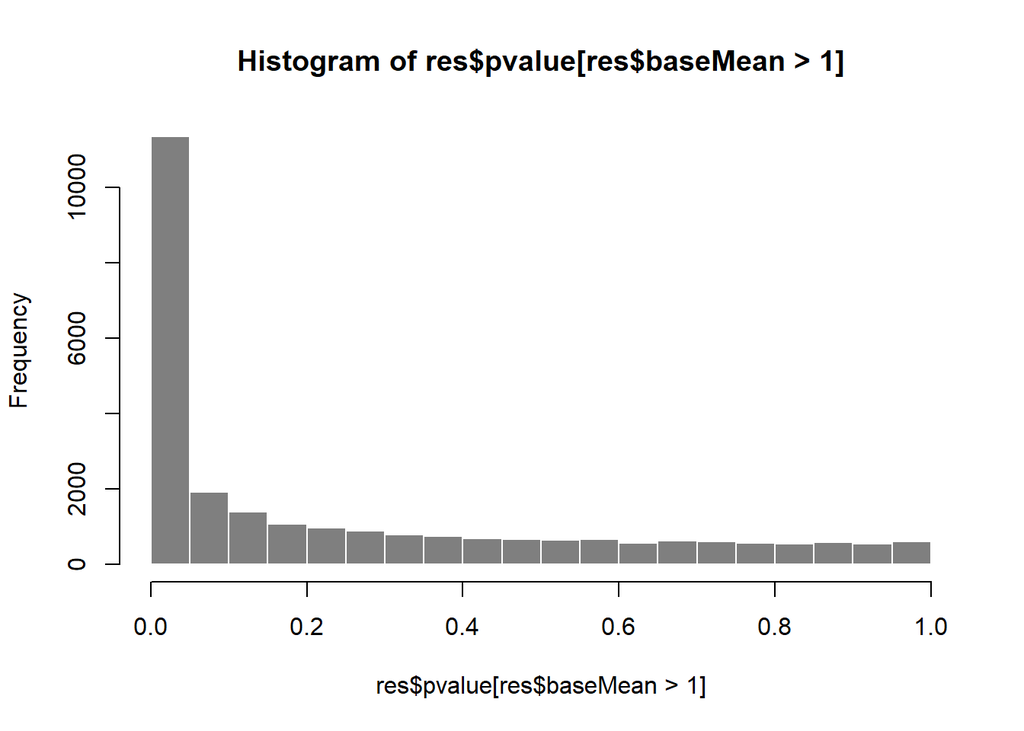

```r
hist(res$pvalue[res$baseMean > 1], breaks = 0:20/20,
     col = "grey50", border = "white")
```

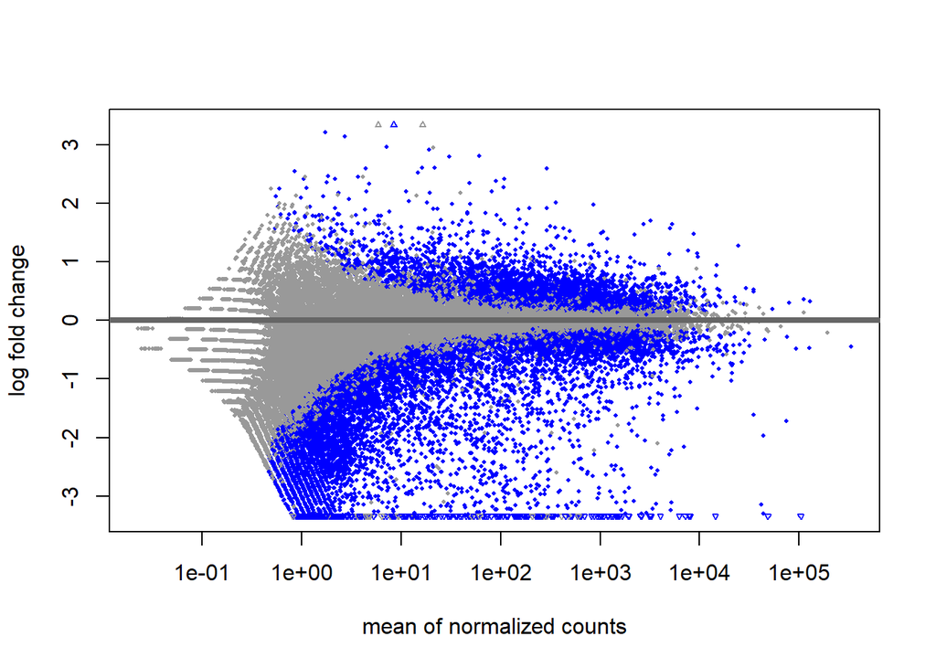

```r
plotMA(res)
```

- For shrinking log fold-change we need to know the ‘name’ of the analysis we want to shrink its results.

```r
resultsNames(dds)
```

```
## [1] "Intercept"                   "disease_Healthy_vs_COVID.19"
```

```r
resLFC <- lfcShrink(dds, coef="disease_Healthy_vs_COVID.19", type="apeglm")
```

```
## using 'apeglm' for LFC shrinkage. If used in published research, please cite:
##     Zhu, A., Ibrahim, J.G., Love, M.I. (2018) Heavy-tailed prior distributions for
##     sequence count data: removing the noise and preserving large differences.
##     Bioinformatics. https://doi.org/10.1093/bioinformatics/bty895
```

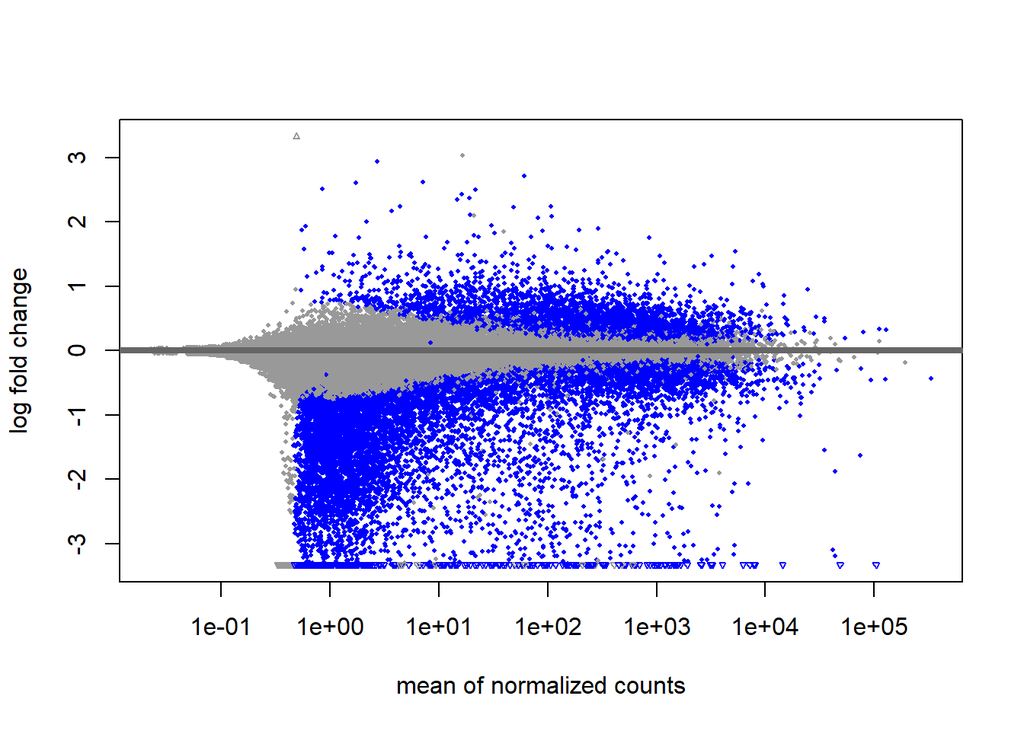

```r
plotMA(resLFC)
```

Adding gene symbols to the results

```r
library("org.Hs.eg.db")
```

```r
# Map gene symbols to the ENSEMBL gene IDs from our data
resLFC$symbol <- mapIds(org.Hs.eg.db,
                        keys=rownames(resLFC),
                        column="SYMBOL",
                        keytype="ENSEMBL",
                        multiVals="first")
```

- Order the results by pvalue:

```r
resOrdered <- resLFC[order(resLFC$pvalue),]
resOrdered
```

```
## log2 fold change (MAP): disease Healthy vs COVID.19
## Wald test p-value: disease Healthy vs COVID.19
## DataFrame with 60683 rows and 6 columns
##                  baseMean log2FoldChange     lfcSE      pvalue        padj
##                 <numeric>      <numeric> <numeric>   <numeric>   <numeric>
## ENSG00000167900   471.054       -3.18133  0.180504 1.04555e-70 3.43714e-66
## ENSG00000166851   189.710       -3.85383  0.222130 1.37961e-68 2.26766e-64
## ENSG00000145386   184.417       -3.72911  0.218714 2.51124e-66 2.75182e-62
## ENSG00000171848   865.664       -3.79574  0.223258 5.29987e-66 4.35570e-62
## ENSG00000175063   144.781       -3.54217  0.211276 2.87958e-64 1.89327e-60
## ...                   ...            ...       ...         ...         ...
## ENSG00000273532     0.000             NA        NA          NA          NA
## ENSG00000276351     0.000             NA        NA          NA          NA
## ENSG00000275661     0.000             NA        NA          NA          NA
## ENSG00000277856   603.898       -4.36707  0.625568          NA          NA
## ENSG00000268674     0.000             NA        NA          NA          NA
##                      symbol
##                 <character>
## ENSG00000167900         TK1
## ENSG00000166851        PLK1
## ENSG00000145386       CCNA2
## ENSG00000171848        RRM2
## ENSG00000175063       UBE2C
## ...                     ...
## ENSG00000273532          NA
## ENSG00000276351          NA
## ENSG00000275661          NA
## ENSG00000277856          NA
## ENSG00000268674          NA
```

## Visualization of gene expression - Example for a specific significant gene

We’ll use the PLK1 gene as our example

```r
i <- which(resOrdered$symbol=='PLK1')
resOrdered[i,]
```

```
## log2 fold change (MAP): disease Healthy vs COVID.19
## Wald test p-value: disease Healthy vs COVID.19
## DataFrame with 1 row and 6 columns
##                  baseMean log2FoldChange     lfcSE      pvalue        padj
##                 <numeric>      <numeric> <numeric>   <numeric>   <numeric>
## ENSG00000166851    189.71       -3.85383   0.22213 1.37961e-68 2.26766e-64
##                      symbol
##                 <character>
## ENSG00000166851        PLK1
```

extract the normalized values of the gene of PLK1:

```r
d <- plotCounts(dds, gene=rownames(resOrdered)[i], intgroup="disease", returnData=TRUE)
d
```

```
##                              count  disease
## S147_nCoV001EUHM-Draw-1  194.66079 COVID-19
## S149_nCoV002EUHM-Draw-2  249.84048 COVID-19
## S150_nCoV003EUHM-Draw-1  816.88318 COVID-19
## S151_nCoV004EUHM-Draw-1  505.80818 COVID-19
## S152_nCoV006EUHM-Draw-1  291.02150 COVID-19
## S153_nCoV007EUHM-Draw-1  192.34488 COVID-19
## S154_nCoV0010EUHM-Draw-1 265.83485 COVID-19
## S155_nCOV021EUHM         619.83892 COVID-19
## S156_nCOV024EUHM-Draw-1  343.39689 COVID-19
## S157_nCOV0029EUHM        471.96562 COVID-19
## S175_nCoV024EUHM-Draw-2  217.61520 COVID-19
## S176_nCoV025EUHM-Draw-1  541.56665 COVID-19
## S177_nCoV025EUHM-Draw-2  301.25702 COVID-19
## S178_nCoV028EUHM-Draw-1  308.31038 COVID-19
## S179_nCoV033EUHM-Draw-1  157.99665 COVID-19
## S180_nCoV034EUHM-Draw-1  368.84652 COVID-19
## S061_257                  27.92331  Healthy
## S062_258                  33.34785  Healthy
## S063_259                  16.12620  Healthy
## S064_260                  20.67065  Healthy
## S065_261                  42.26374  Healthy
## S066_265                  28.47792  Healthy
## S067_270                  20.08557  Healthy
## S068_272                  32.62572  Healthy
## S069_273                  26.86873  Healthy
## S070_279                  18.56049  Healthy
## S071_280                  35.91645  Healthy
## S181_255                  22.79724  Healthy
## S182_SHXA10               13.09413  Healthy
## S183_263                   8.72798  Healthy
## S184_SHXA18               45.71783  Healthy
## S185_266                  13.94792  Healthy
## S186_SHXA14               22.57992  Healthy
```

- Plotting a box plot with ggplot2

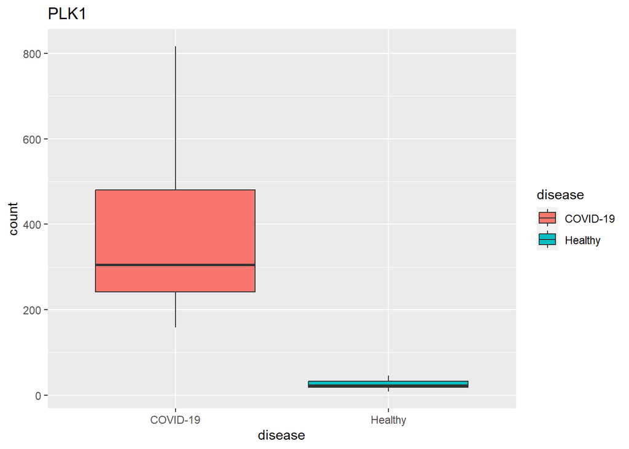

```r
ggplot(d, aes(disease, count)) + geom_boxplot(aes(fill=disease)) + ggtitle("PLK1")
```

- Adding the samples to the plot

```r
library(viridis) # color palettes
```

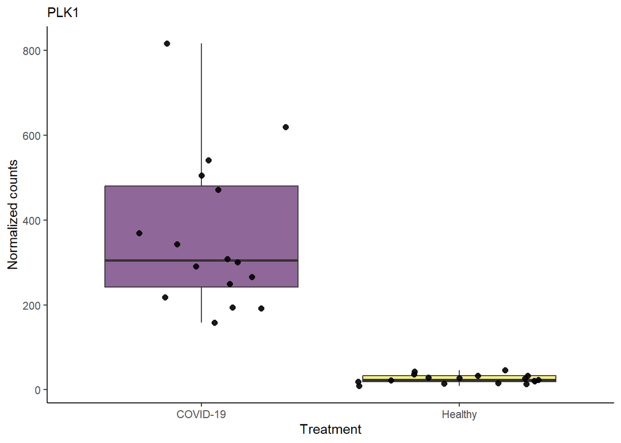

```r
ggplot(d, aes(x=disease, y=count,fill=disease)) +
  geom_boxplot() +
  scale_fill_viridis(discrete = TRUE, alpha=0.6) +
  geom_jitter(color="black", size=2, alpha=0.9) +
  theme_classic() +
  theme(
    legend.position="none",
    plot.title = element_text(size=11)
  ) +
  ggtitle("PLK1") +
  xlab("Treatment") + ylab("Normalized counts")
```

## Visualization of gene expression for multiple genes

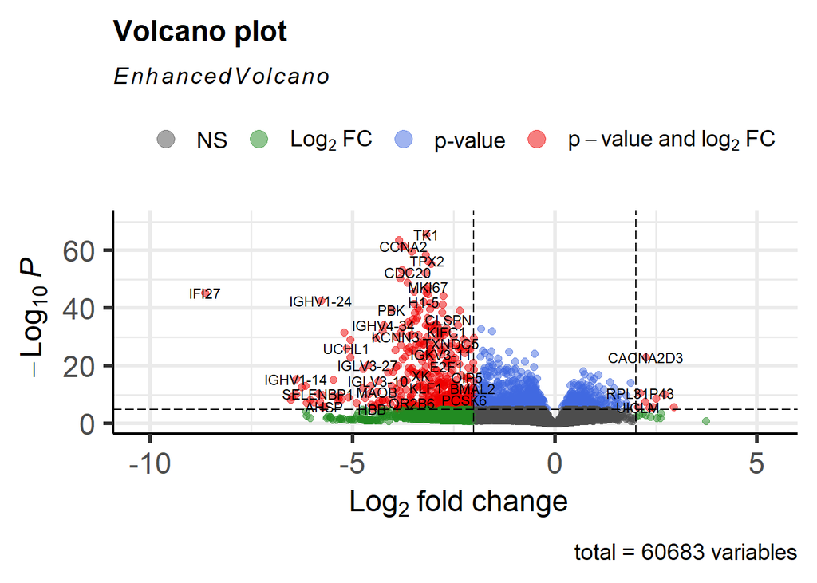

```r
library(EnhancedVolcano)
EnhancedVolcano(resOrdered,
                lab = resOrdered$symbol,
                x = 'log2FoldChange',
                y = 'padj',
                labSize=3,
                FCcutoff=2 )
```

- visualize multiple genes with a heatmap:

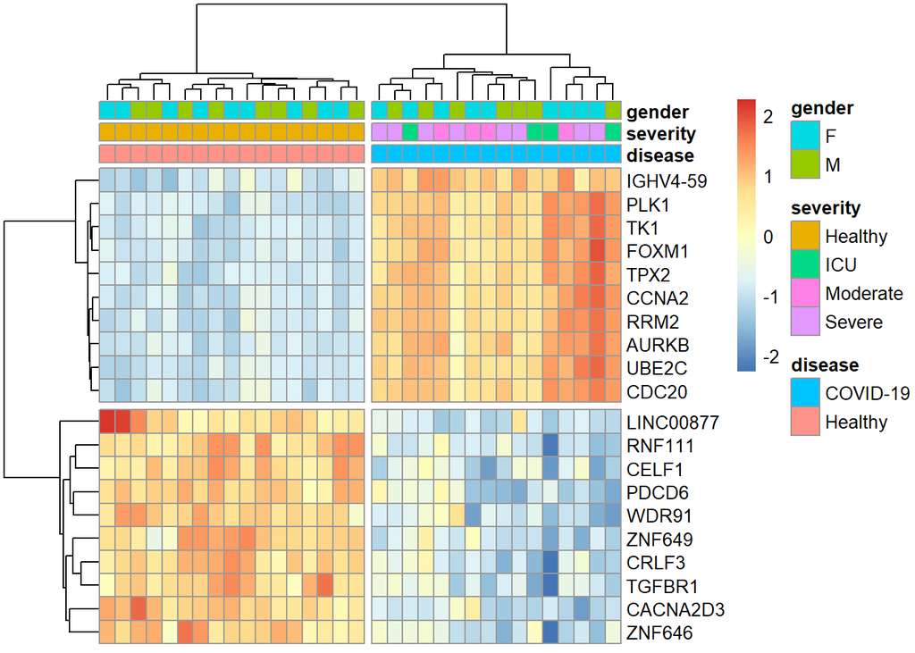

```r
library(pheatmap)

dds.symbol = dds
rownames(dds.symbol) = mapIds(org.Hs.eg.db,
                              keys=rownames(dds),
                              column="SYMBOL",
                              keytype="ENSEMBL",
                              multiVals="first")
rownames(dds.symbol)[is.na(rownames(dds.symbol))] = rownames(dds)[is.na(rownames(dds.symbol))]
rownames(dds.symbol) = make.unique(rownames(dds.symbol))
selectUp <- resOrdered$symbol[resOrdered$log2FoldChange>0][1:10]
selectDown <- resOrdered$symbol[resOrdered$log2FoldChange<0][1:10]
select = c(selectUp,selectDown)
df <- data.frame(row.names = colnames(dds.symbol),
                 disease = colData(dds.symbol)$disease,
                 severity = colData(dds.symbol)$severity,
                 gender = colData(dds.symbol)$gender)
### get normalized counts (also try rlog, and counts with normalized=T)
normcounts = assay(vst(dds.symbol,blind=T))
pheatmap(normcounts[select,], cluster_rows=TRUE,
         show_colnames = FALSE,cluster_cols=TRUE,
         annotation_col=df, scale = 'row',cutree_cols = 2,cutree_rows = 2)
```

We can notice a nice “clustering” for each “disease” option, in relation to different counts of gene groups.

## Next We’ll perform almost the same analysis on the second dataset

## accession number - GSE171110 (dataset 2)

```r
setwd('C:/Users/Ofer/OneDrive - Technion/Documents/236523/final')
counts2 <- read_table("GSE171110_Data_RNAseq_raw_counts_geo.txt.gz")
gse2 <- getGEO(filename="GSE171110_series_matrix.txt")
```

Let’s take a look at the second counts table

```r
head(counts2)
```

```
## # A tibble: 6 × 55
##   Sample_sheet `507-V`  `1189-V` 1406-…¹ 1918-…² 1951-…³ 1995-…⁴ 2064-…⁵ 3054-…⁶
##   <chr>        <chr>    <chr>    <chr>   <chr>   <chr>   <chr>   <chr>   <chr>
## 1 Sample_ID    507      1189     1406    1918    1951    1995    2064    3054
## 2 Code_Patient 507-V    1189-V   1406-V  1918-V  1951-V  1995-V  2064-V  3054-V
## 3 A1BG         133.1436 110.142… 94.6867 89.600… 85.814… 59.033… 77.183… 64.633…
## 4 A1CF         9        8.00000… 1.0000… 10.000… 3.0000… 6       4.0000… 5.0000…
## 5 A2M          65.00001 31.7205… 36.635… 19.225… 27.999… 40.603… 34.000… 31.562…
## 6 A2ML1        29.28124 26.3047  20.579… 13      5       39.4716 8.13204 20.040…
## # … with 46 more variables: `3136-V` <chr>, `3538-V` <chr>, `1-C` <chr>,
## #   `9-C` <chr>, `12-C` <chr>, `18-C` <chr>, `19-C` <chr>, `21-C` <chr>,
## #   `24-C` <chr>, `25-C` <chr>, `26-C` <chr>, `28-C` <chr>, `29-C` <chr>,
## #   `30-C` <chr>, `32-C` <chr>, `33-C` <chr>, `34-C` <chr>, `36-C` <chr>,
## #   `37-C` <chr>, `38-C` <chr>, `41-C` <chr>, `42-C` <chr>, `43-C` <chr>,
## #   `56` <chr>, `58` <chr>, `62` <chr>, `65` <chr>, `66` <chr>, `67` <chr>,
## #   `69` <chr>, `70` <chr>, `71` <chr>, `72` <chr>, `73` <chr>, `74` <chr>, …
```

We can see it differs a bit from the first dataset (averaged counts, and including not just gene symbols nor ensemble ids but numbers of gene transcripts such as AC003072.1)

- So, let’s pre-process it.

```r
library(data.table)
# Remove first two irrelevant rows (Sample_ID, Code_Patient)
counts2 <- counts2[3:nrow(counts2), ]

# Keep only SYMBOLS to fit the first dataset
counts2 <- counts2[counts2$Sample_sheet %in% keys(org.Hs.eg.db, keytype="SYMBOL"), ]

# Round all counts elements (which are currently of 'chr' type)
for (i in seq_along(counts2[, 2:ncol(counts2)])) {
  for (j in seq_along(counts2[ , 2:ncol(counts2)][[i]])) {
    counts2[ , 2:ncol(counts2)][[i]][[j]] <- gsub("\\..*$", "", counts2[ , 2:ncol(counts2)][[i]][[j]])
  }
}
```

- Look at the pre-proccessed counts matrix for the second data set:

```r
head(counts2)
```

```
## # A tibble: 6 × 55
##   Sample_sheet `507-V` `1189-V` `1406-V` 1918-…¹ 1951-…² 1995-…³ 2064-…⁴ 3054-…⁵
##   <chr>        <chr>   <chr>    <chr>    <chr>   <chr>   <chr>   <chr>   <chr>
## 1 A1BG         133     110      94       89      85      59      77      64
## 2 A1CF         9       8        1        10      3       6       4       5
## 3 A2M          65      31       36       19      27      40      34      31
## 4 A2ML1        29      26       20       13      5       39      8       20
## 5 A2MP1        262     83       98       55      41      124     49      56
## 6 A3GALT2      12      1        5        7       0       1       5       0
## # … with 46 more variables: `3136-V` <chr>, `3538-V` <chr>, `1-C` <chr>,
## #   `9-C` <chr>, `12-C` <chr>, `18-C` <chr>, `19-C` <chr>, `21-C` <chr>,
## #   `24-C` <chr>, `25-C` <chr>, `26-C` <chr>, `28-C` <chr>, `29-C` <chr>,
## #   `30-C` <chr>, `32-C` <chr>, `33-C` <chr>, `34-C` <chr>, `36-C` <chr>,
## #   `37-C` <chr>, `38-C` <chr>, `41-C` <chr>, `42-C` <chr>, `43-C` <chr>,
## #   `56` <chr>, `58` <chr>, `62` <chr>, `65` <chr>, `66` <chr>, `67` <chr>,
## #   `69` <chr>, `70` <chr>, `71` <chr>, `72` <chr>, `73` <chr>, `74` <chr>, …
```

- Load the metadata of the second set

```r
metadata2 <- as_tibble(gse2)
head(metadata2)
```

```
## # A tibble: 6 × 37
##   title     geo_a…¹ status submi…² last_…³ type  chann…⁴ sourc…⁵ organ…⁶ chara…⁷
##   <chr>     <chr>   <chr>  <chr>   <chr>   <chr> <chr>   <chr>   <chr>   <chr>
## 1 507-V He… GSM521… Publi… Mar 29… May 27… SRA   1       Blood   Homo s… status…
## 2 1189-V H… GSM521… Publi… Mar 29… May 27… SRA   1       Blood   Homo s… status…
## 3 1406-V H… GSM521… Publi… Mar 29… May 27… SRA   1       Blood   Homo s… status…
## 4 1918-V H… GSM521… Publi… Mar 29… May 27… SRA   1       Blood   Homo s… status…
## 5 1951-V H… GSM521… Publi… Mar 29… May 27… SRA   1       Blood   Homo s… status…
## 6 1995-V H… GSM521… Publi… Mar 29… May 27… SRA   1       Blood   Homo s… status…
## # … with 27 more variables: molecule_ch1 <chr>, extract_protocol_ch1 <chr>,
## #   extract_protocol_ch1.1 <chr>, taxid_ch1 <chr>, description <chr>,
## #   description.1 <chr>, data_processing <chr>, data_processing.1 <chr>,
## #   data_processing.2 <chr>, data_processing.3 <chr>, platform_id <chr>,
## #   contact_name <chr>, contact_email <chr>, contact_institute <chr>,
## #   contact_address <chr>, contact_city <chr>, contact_zip.postal_code <chr>,
## #   contact_country <chr>, data_row_count <chr>, instrument_model <chr>, …
```

- We can notice un-wanted suffix for the samples. Let’s remove it to fit the cols of counts2.

```r
metadata2$title <- gsub(" Healthy\\b(.{0,8})$", "", metadata2$title)
metadata2$title <- gsub(" Severe Covid-19\\b(.{0,16})$", "", metadata2$title)
head(metadata2)
```

```
## # A tibble: 6 × 37
##   title  geo_acce…¹ status submi…² last_…³ type  chann…⁴ sourc…⁵ organ…⁶ chara…⁷
##   <chr>  <chr>      <chr>  <chr>   <chr>   <chr> <chr>   <chr>   <chr>   <chr>
## 1 507-V  GSM5218990 Publi… Mar 29… May 27… SRA   1       Blood   Homo s… status…
## 2 1189-V GSM5218991 Publi… Mar 29… May 27… SRA   1       Blood   Homo s… status…
## 3 1406-V GSM5218992 Publi… Mar 29… May 27… SRA   1       Blood   Homo s… status…
## 4 1918-V GSM5218993 Publi… Mar 29… May 27… SRA   1       Blood   Homo s… status…
## 5 1951-V GSM5218994 Publi… Mar 29… May 27… SRA   1       Blood   Homo s… status…
## 6 1995-V GSM5218995 Publi… Mar 29… May 27… SRA   1       Blood   Homo s… status…
## # … with 27 more variables: molecule_ch1 <chr>, extract_protocol_ch1 <chr>,
## #   extract_protocol_ch1.1 <chr>, taxid_ch1 <chr>, description <chr>,
## #   description.1 <chr>, data_processing <chr>, data_processing.1 <chr>,
## #   data_processing.2 <chr>, data_processing.3 <chr>, platform_id <chr>,
## #   contact_name <chr>, contact_email <chr>, contact_institute <chr>,
## #   contact_address <chr>, contact_city <chr>, contact_zip.postal_code <chr>,
## #   contact_country <chr>, data_row_count <chr>, instrument_model <chr>, …
```

- Select relevant column in metadata
  - This time we don’t have ‘gender’ nor ‘severity’ (all the patients with COVID-19 have severe condition). This is not critical as we’re not planning to use the ‘’gender’ in the design anyway.

```r
metadata2 <- metadata2 %>%
  dplyr::select(sample = title, disease = status.ch1)
head(metadata2)
```

```
## # A tibble: 6 × 2
##   sample disease
##   <chr>  <chr>
## 1 507-V  Healthy
## 2 1189-V Healthy
## 3 1406-V Healthy
## 4 1918-V Healthy
## 5 1951-V Healthy
## 6 1995-V Healthy
```

- Check distribution of samples (Healthy vs severe COVID-19)

```r
table(metadata2$disease)
```

```
##
##         Healthy Severe Covid-19
##              10              44
```

- Make sure the counts matrix corresponds to the metadata

```r
metadata2$sample == colnames(counts2)[-1]
```

```
##  [1] TRUE TRUE TRUE TRUE TRUE TRUE TRUE TRUE TRUE TRUE TRUE TRUE TRUE TRUE TRUE
## [16] TRUE TRUE TRUE TRUE TRUE TRUE TRUE TRUE TRUE TRUE TRUE TRUE TRUE TRUE TRUE
## [31] TRUE TRUE TRUE TRUE TRUE TRUE TRUE TRUE TRUE TRUE TRUE TRUE TRUE TRUE TRUE
## [46] TRUE TRUE TRUE TRUE TRUE TRUE TRUE TRUE TRUE
```

- Set disease state as a factor

```r
class(metadata2$disease)
```

```
## [1] "character"
```

```r
metadata2 <- mutate(metadata2, disease = as.factor(disease))
class(metadata2$disease)
```

```
## [1] "factor"
```

```r
head(metadata2$disease)
```

```
## [1] Healthy Healthy Healthy Healthy Healthy Healthy
## Levels: Healthy Severe Covid-19
```

Prepare counts2 for DESeq2

```r
# Make all counts cols numeric for the DESeq2
counts2[2:ncol(counts2)] <- apply(counts2[2:ncol(counts2)], 2, as.numeric)

sample_sheet <- counts2$Sample_sheet
# Make all row names informative (analogical to the ENSEMBLEID)
rownames(counts2) <- sample_sheet
head(counts2)
```

```
## # A tibble: 6 × 55
##   Sample_sheet `507-V` `1189-V` `1406-V` 1918-…¹ 1951-…² 1995-…³ 2064-…⁴ 3054-…⁵
##   <chr>          <dbl>    <dbl>    <dbl>   <dbl>   <dbl>   <dbl>   <dbl>   <dbl>
## 1 A1BG             133      110       94      89      85      59      77      64
## 2 A1CF               9        8        1      10       3       6       4       5
## 3 A2M               65       31       36      19      27      40      34      31
## 4 A2ML1             29       26       20      13       5      39       8      20
## 5 A2MP1            262       83       98      55      41     124      49      56
## 6 A3GALT2           12        1        5       7       0       1       5       0
## # … with 46 more variables: `3136-V` <dbl>, `3538-V` <dbl>, `1-C` <dbl>,
## #   `9-C` <dbl>, `12-C` <dbl>, `18-C` <dbl>, `19-C` <dbl>, `21-C` <dbl>,
## #   `24-C` <dbl>, `25-C` <dbl>, `26-C` <dbl>, `28-C` <dbl>, `29-C` <dbl>,
## #   `30-C` <dbl>, `32-C` <dbl>, `33-C` <dbl>, `34-C` <dbl>, `36-C` <dbl>,
## #   `37-C` <dbl>, `38-C` <dbl>, `41-C` <dbl>, `42-C` <dbl>, `43-C` <dbl>,
## #   `56` <dbl>, `58` <dbl>, `62` <dbl>, `65` <dbl>, `66` <dbl>, `67` <dbl>,
## #   `69` <dbl>, `70` <dbl>, `71` <dbl>, `72` <dbl>, `73` <dbl>, `74` <dbl>, …
```

- Make sure the counts matrix corresponds to the metadata

```r
counts2 <- cbind(Sample_sheet = counts2$Sample_sheet, counts2[,metadata2$sample])
metadata2$sample == colnames(counts2)[-1]
```

```
##  [1] TRUE TRUE TRUE TRUE TRUE TRUE TRUE TRUE TRUE TRUE TRUE TRUE TRUE TRUE TRUE
## [16] TRUE TRUE TRUE TRUE TRUE TRUE TRUE TRUE TRUE TRUE TRUE TRUE TRUE TRUE TRUE
## [31] TRUE TRUE TRUE TRUE TRUE TRUE TRUE TRUE TRUE TRUE TRUE TRUE TRUE TRUE TRUE
## [46] TRUE TRUE TRUE TRUE TRUE TRUE TRUE TRUE TRUE
```

- Constructs a DESeq2 object

```r
dds2 <- DESeqDataSetFromMatrix(countData=counts2,
                               colData=metadata2,
                               design= ~disease,
                               tidy=TRUE)
```

```
##   Note: levels of factors in the design contain characters other than
##   letters, numbers, '_' and '.'. It is recommended (but not required) to use
##   only letters, numbers, and delimiters '_' or '.', as these are safe characters
##   for column names in R. [This is a message, not a warning or an error]
```

- Next we run DESeq2 from start to end in a single command

```r
dds2 <- DESeq(dds2)
```

[output not shown]

[output not shown]

[output not shown]

[output not shown]

```
## -- replacing outliers and refitting for 287 genes
## -- DESeq argument 'minReplicatesForReplace' = 7
## -- original counts are preserved in counts(dds)
```

[output not shown]

[output not shown]

Next we’ll look again at the gene-wise dispersion and the distribution of gene expression.

```r
dds2 <- estimateDispersions(dds2)
```

```
## found already estimated dispersions, replacing these
```

[output not shown]

[output not shown]

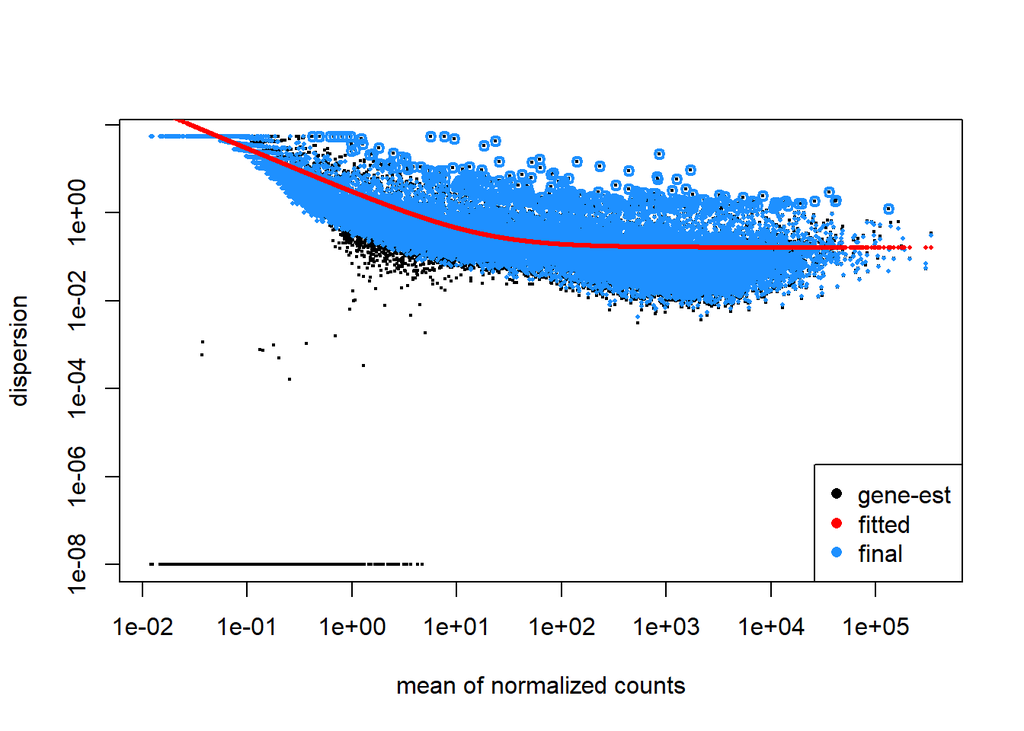

```r
plotDispEsts(dds2)
```

- The distribution of gene expression

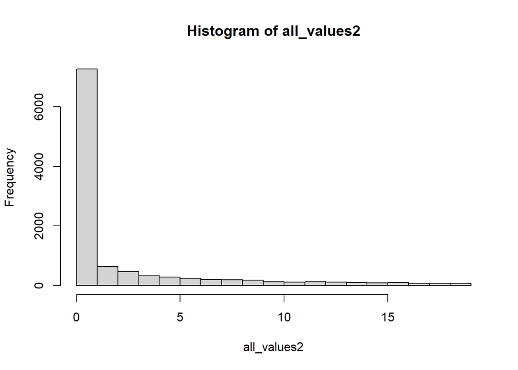

```r
all_values2 <- pull(counts2[,-1])
all_values2 <- all_values2[all_values2<20]
hist(all_values2, breaks = 20)
```

We can see that we get really similar plots to what we have gotten for the first dataset. Hence, we’ll use the same solution.

- Solution: Negative binomial distribution, Wald test

```r
dds2 <- nbinomWaldTest(dds2)
```

- Getting differential expression results:

```r
res2 <- results(dds2)
# View(as.data.frame(res2))
mcols(res2, use.names=T)
```

```
## DataFrame with 6 rows and 2 columns
##                        type            description
##                 <character>            <character>
## baseMean       intermediate mean of normalized c..
## log2FoldChange      results log2 fold change (ML..
## lfcSE               results standard error: dise..
## stat                results Wald statistic: dise..
## pvalue              results Wald test p-value: d..
## padj                results   BH adjusted p-values
```

```r
summary(res2)
```

```
##
## out of 24161 with nonzero total read count
## adjusted p-value < 0.1
## LFC > 0 (up)       : 5913, 24%
## LFC < 0 (down)     : 4754, 20%
## outliers [1]       : 284, 1.2%
## low counts [2]     : 4209, 17%
## (mean count < 0)
## [1] see 'cooksCutoff' argument of ?results
## [2] see 'independentFiltering' argument of ?results
```

distribution of p-values:

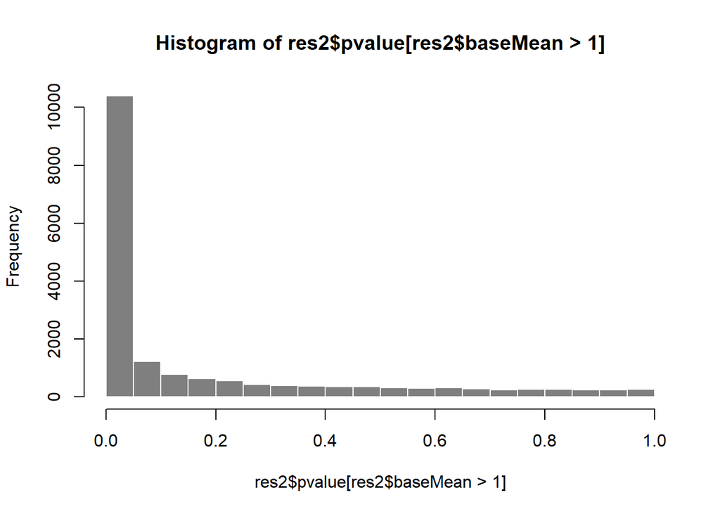

```r
hist(res2$pvalue[res2$baseMean > 1], breaks = 0:20/20,
     col = "grey50", border = "white")
```

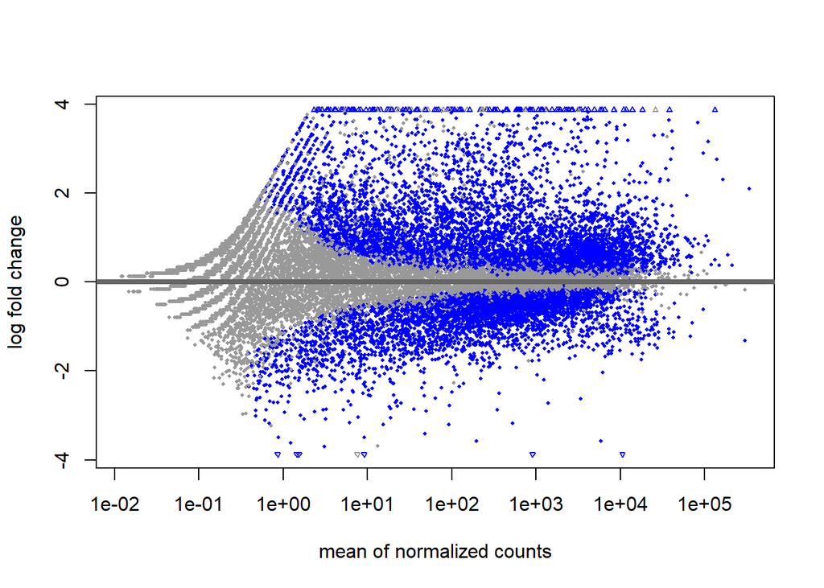

```r
plotMA(res2)
```

- For shrinking log fold-change we need to know the ‘name’ of the analysis we want to shrink its results.

```r
resultsNames(dds2)
```

```
## [1] "Intercept"                          "disease_Severe.Covid.19_vs_Healthy"
```

```r
resLFC2 <- lfcShrink(dds2, coef="disease_Severe.Covid.19_vs_Healthy", type="apeglm")
```

```
## using 'apeglm' for LFC shrinkage. If used in published research, please cite:
##     Zhu, A., Ibrahim, J.G., Love, M.I. (2018) Heavy-tailed prior distributions for
##     sequence count data: removing the noise and preserving large differences.
##     Bioinformatics. https://doi.org/10.1093/bioinformatics/bty895
```

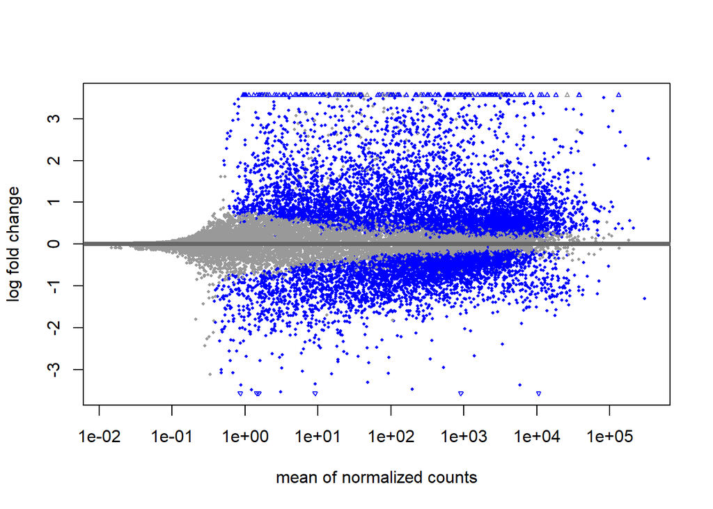

```r
plotMA(resLFC2)
```

- Adding gene symbols to the results

```r
resLFC2$symbol <- rownames(resLFC2)
```

- Order the results by pvalue:

```r
resOrdered2 <- resLFC2[order(resLFC2$pvalue),]
resOrdered2
```

```
## log2 fold change (MAP): disease Severe.Covid.19 vs Healthy
## Wald test p-value: disease Severe.Covid.19 vs Healthy
## DataFrame with 24870 rows and 6 columns
##            baseMean log2FoldChange     lfcSE      pvalue        padj
##           <numeric>      <numeric> <numeric>   <numeric>   <numeric>
## BRCA1       788.294        1.43862  0.119910 3.44116e-34 6.76807e-30
## SDC1        457.307        5.61973  0.483902 2.57472e-33 2.53198e-29
## GTSE1       300.931        2.68164  0.234671 7.92782e-32 5.19748e-28
## MYBL2      2227.355        3.59912  0.321780 1.01702e-30 5.00070e-27
## MCM10       276.143        3.07156  0.276657 2.22623e-30 8.75710e-27
## ...             ...            ...       ...         ...         ...
## ZNF705G      0.0000             NA        NA          NA          NA
## ZNF72P       0.0000             NA        NA          NA          NA
## ZNF736P8Y    0.0000             NA        NA          NA          NA
## ZNF826P     84.4369     -0.0890333  0.244204          NA          NA
## ZP3P2        0.0000             NA        NA          NA          NA
##                symbol
##           <character>
## BRCA1           BRCA1
## SDC1             SDC1
## GTSE1           GTSE1
## MYBL2           MYBL2
## MCM10           MCM10
## ...               ...
## ZNF705G       ZNF705G
## ZNF72P         ZNF72P
## ZNF736P8Y   ZNF736P8Y
## ZNF826P       ZNF826P
## ZP3P2           ZP3P2
```

## Visualization of gene expression - Example for a specific significant gene

We’ll use the BRCA1 gene as our example for this dataset

```r
i <- which(resOrdered2$symbol=='BRCA1')
resOrdered2[i,]
```

```
## log2 fold change (MAP): disease Severe.Covid.19 vs Healthy
## Wald test p-value: disease Severe.Covid.19 vs Healthy
## DataFrame with 1 row and 6 columns
##        baseMean log2FoldChange     lfcSE      pvalue        padj      symbol
##       <numeric>      <numeric> <numeric>   <numeric>   <numeric> <character>
## BRCA1   788.294        1.43862   0.11991 3.44116e-34 6.76807e-30       BRCA1
```

We’ll extract the normalized values of the gene of BRCA1:

```r
d2 <- plotCounts(dds2, gene=rownames(resOrdered2)[i], intgroup="disease", returnData=TRUE)
d2
```

```
##            count         disease
## 507-V   345.9086         Healthy
## 1189-V  273.4019         Healthy
## 1406-V  299.6352         Healthy
## 1918-V  241.5408         Healthy
## 1951-V  267.9641         Healthy
## 1995-V  356.5874         Healthy
## 2064-V  278.5132         Healthy
## 3054-V  325.5757         Healthy
## 3136-V  367.8315         Healthy
## 3538-V  508.7988         Healthy
## 1-C     986.5282 Severe Covid-19
## 9-C     877.1160 Severe Covid-19
## 12-C   1154.6266 Severe Covid-19
## 18-C    655.9943 Severe Covid-19
## 19-C    983.0092 Severe Covid-19
## 21-C    798.3757 Severe Covid-19
## 24-C    914.2211 Severe Covid-19
## 25-C    735.3507 Severe Covid-19
## 26-C    820.1345 Severe Covid-19
## 28-C   1005.1202 Severe Covid-19
## 29-C    781.2420 Severe Covid-19
## 30-C    684.2992 Severe Covid-19
## 32-C    902.3450 Severe Covid-19
## 33-C   1327.1894 Severe Covid-19
## 34-C   1056.9067 Severe Covid-19
## 36-C   1021.4866 Severe Covid-19
## 37-C    655.2502 Severe Covid-19
## 38-C   1260.0159 Severe Covid-19
## 41-C    722.3425 Severe Covid-19
## 42-C    651.5325 Severe Covid-19
## 43-C   1075.5037 Severe Covid-19
## 56      798.1998 Severe Covid-19
## 58      591.1747 Severe Covid-19
## 62      755.0825 Severe Covid-19
## 65      903.7025 Severe Covid-19
## 66      740.3698 Severe Covid-19
## 67      887.9094 Severe Covid-19
## 69      660.5703 Severe Covid-19
## 70     1022.9134 Severe Covid-19
## 71      802.3715 Severe Covid-19
## 72      775.1803 Severe Covid-19
## 73     1161.8994 Severe Covid-19
## 74      879.8125 Severe Covid-19
## 77      913.0662 Severe Covid-19
## 81      652.2027 Severe Covid-19
## 82      794.5499 Severe Covid-19
## 83     1018.6173 Severe Covid-19
## 84      663.0235 Severe Covid-19
## 85      853.2098 Severe Covid-19
## 87      959.8960 Severe Covid-19
## 91     1778.0515 Severe Covid-19
## 92      681.1297 Severe Covid-19
## 95      939.0703 Severe Covid-19
## 101    1028.5478 Severe Covid-19
```

We can see a big difference between the counts of the healthy and the ones of the disease.

- Plotting a box plot with ggplot2 (for visual difference)

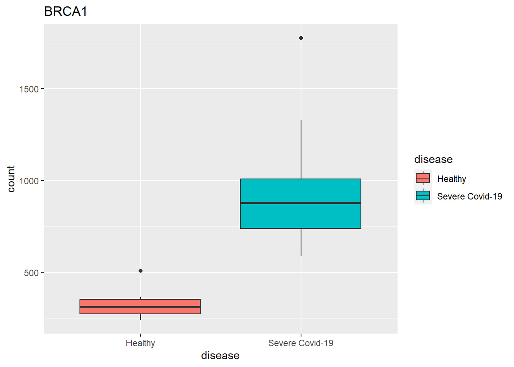

```r
ggplot(d2, aes(disease, count)) + geom_boxplot(aes(fill=disease)) + ggtitle("BRCA1")
```

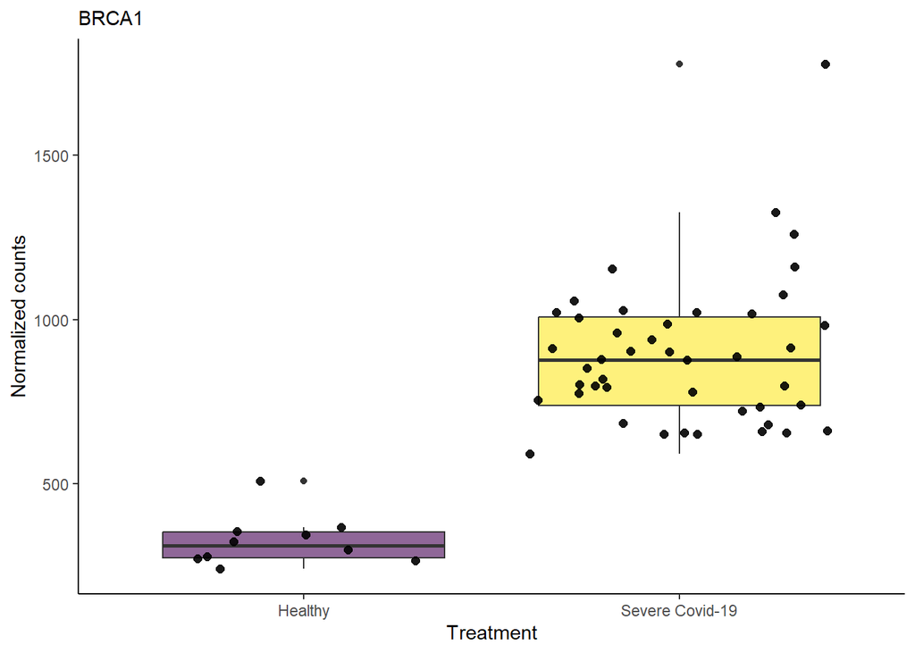

```r
ggplot(d2, aes(x=disease, y=count,fill=disease)) +
  geom_boxplot() +
  scale_fill_viridis(discrete = TRUE, alpha=0.6) +
  geom_jitter(color="black", size=2, alpha=0.9) +
  theme_classic() +
  theme(
    legend.position="none",
    plot.title = element_text(size=11)
  ) +
  ggtitle("BRCA1") +
  xlab("Treatment") + ylab("Normalized counts")
```

## Visualization of gene expression for multiple genes

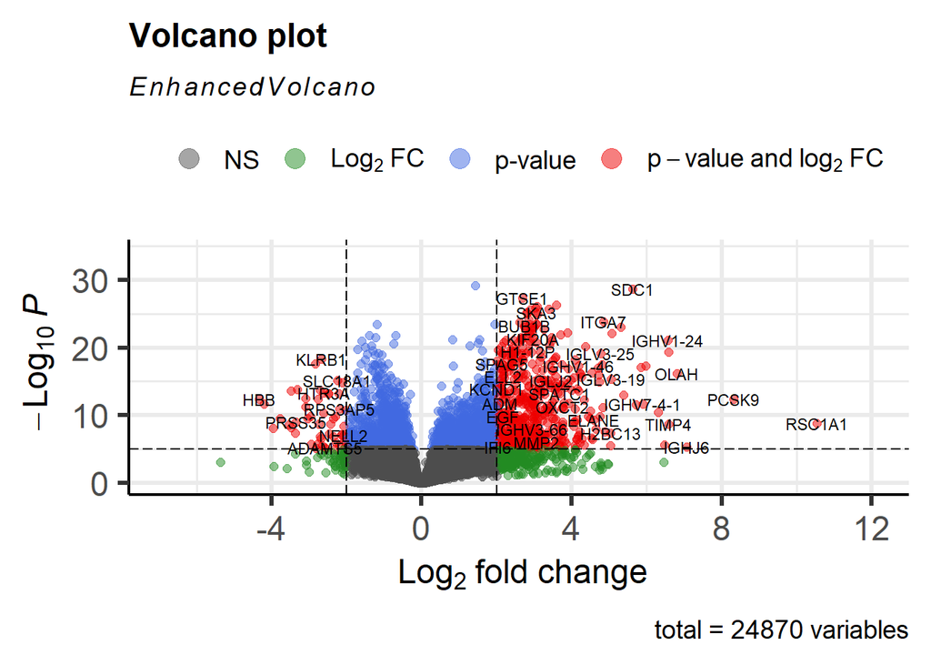

```r
EnhancedVolcano(resOrdered2,
                lab = resOrdered2$symbol,
                x = 'log2FoldChange',
                y = 'padj',
                labSize=3,
                FCcutoff=2 )
```

visualize multiple genes with a heatmap:

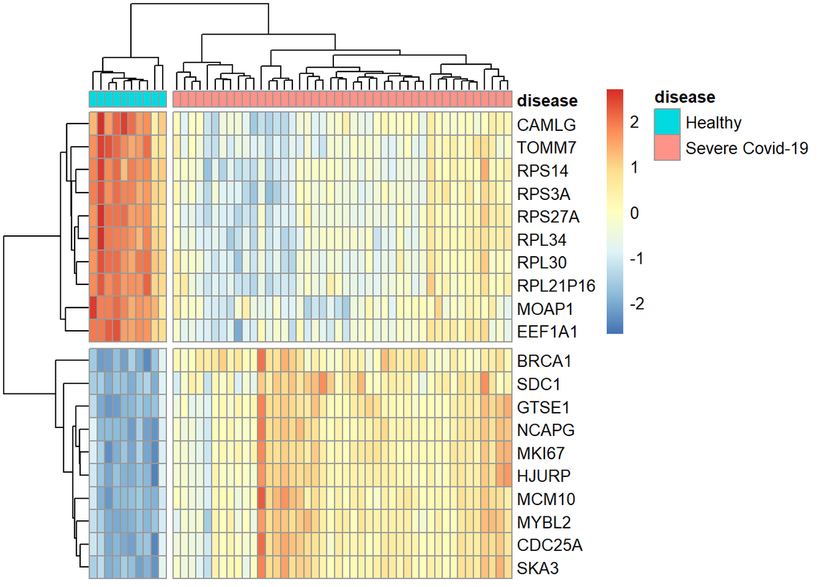

```r
dds2.symbol = dds2
rownames(dds2.symbol)[is.na(rownames(dds2.symbol))] = rownames(dds2)[is.na(rownames(dds2.symbol))]
rownames(dds2.symbol) = make.unique(rownames(dds2.symbol))
selectUp <- resOrdered2$symbol[resOrdered2$log2FoldChange>0][1:10]
selectDown <- resOrdered2$symbol[resOrdered2$log2FoldChange<0][1:10]
select = c(selectUp,selectDown)
df2 <- data.frame(row.names = colnames(dds2.symbol),
                 disease = colData(dds2.symbol)$disease)

### get normalized counts (also try rlog, and counts with normalized=T)
normcounts = assay(vst(dds2.symbol,blind=T))
pheatmap(normcounts[select,], cluster_rows=TRUE,
         show_colnames = FALSE,cluster_cols=TRUE,
         annotation_col=df2, scale = 'row',cutree_cols = 2,cutree_rows = 2)
```

### Intersect the significant genes from both datasets to retrieve more

### reliable DEGs

```r
## Filter non-significant genes from first set
filter.sgn.genes.1 <- resOrdered
filter.sgn.genes.1.nona <- filter.sgn.genes.1[!is.na(filter.sgn.genes.1$padj),]
filter.sgn.genes.1.nona <- filter.sgn.genes.1.nona[filter.sgn.genes.1.nona$padj < 0.05, ]

## Filter non-significant genes from second set
filter.sgn.genes.2 <- resOrdered2
filter.sgn.genes.2.nona <- filter.sgn.genes.2[!is.na(filter.sgn.genes.2$padj),]
filter.sgn.genes.2.nona <- filter.sgn.genes.2.nona[filter.sgn.genes.2.nona$padj < 0.05, ]

# Intersect
filter.intersect.covid <- filter.sgn.genes.1.nona[filter.sgn.genes.1.nona$symbol %in% filter.sgn.genes.2.nona$symbol,]
filter.intersect.covid
```

```
## log2 fold change (MAP): disease Healthy vs COVID.19
## Wald test p-value: disease Healthy vs COVID.19
## DataFrame with 3898 rows and 6 columns
##                   baseMean log2FoldChange     lfcSE      pvalue        padj
##                  <numeric>      <numeric> <numeric>   <numeric>   <numeric>
## ENSG00000167900    471.054       -3.18133  0.180504 1.04555e-70 3.43714e-66
## ENSG00000166851    189.710       -3.85383  0.222130 1.37961e-68 2.26766e-64
## ENSG00000145386    184.417       -3.72911  0.218714 2.51124e-66 2.75182e-62
## ENSG00000171848    865.664       -3.79574  0.223258 5.29987e-66 4.35570e-62
## ENSG00000175063    144.781       -3.54217  0.211276 2.87958e-64 1.89327e-60
## ...                    ...            ...       ...         ...         ...
## ENSG00000141560 524.759733       0.197429 0.0821346   0.0146342   0.0498121
## ENSG00000273111   0.651180      -1.568661 1.5607641   0.0146504   0.0498567
## ENSG00000244116   0.692657      -1.358599 1.3990746   0.0146697   0.0499174
## ENSG00000181031  66.889160       0.405674 0.1798268   0.0146879   0.0499585
## ENSG00000196569  32.047704       0.427817 0.1913590   0.0146902   0.0499614
##                      symbol
##                 <character>
## ENSG00000167900         TK1
## ENSG00000166851        PLK1
## ENSG00000145386       CCNA2
## ENSG00000171848        RRM2
## ENSG00000175063       UBE2C
## ...                     ...
## ENSG00000141560      FN3KRP
## ENSG00000273111       LYPD4
## ENSG00000244116    IGKV2-28
## ENSG00000181031      RPH3AL
## ENSG00000196569       LAMA2
```

- Performing PCA on first COVID-19 dataset:

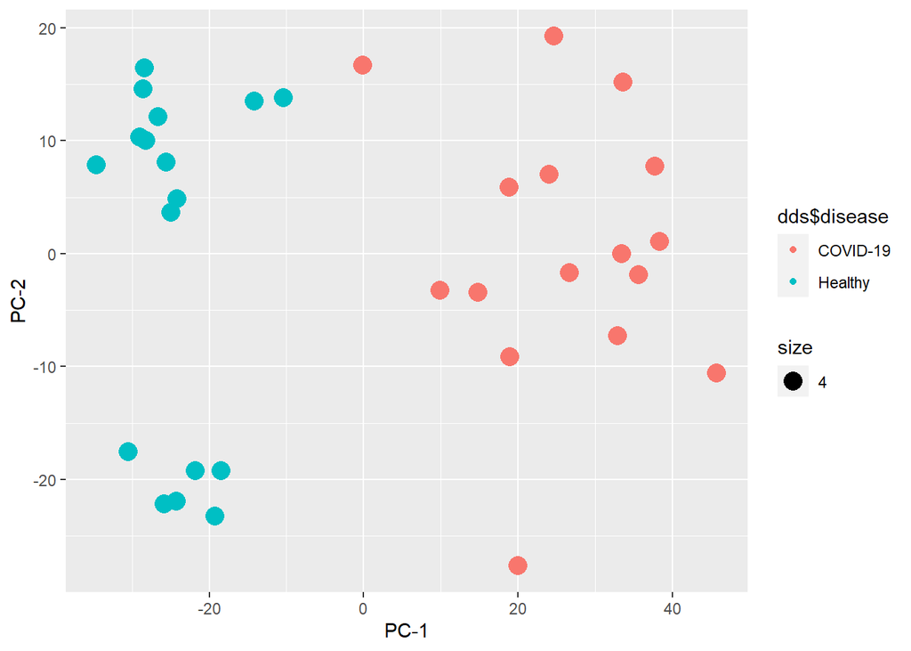

```r
dds.symbol <- dds
normcounts = assay(vst(dds.symbol, blind=T))
var_per_gene <- apply(normcounts, 1, var)  # Calculate the variance per gene
selectedGenes <- names(var_per_gene[order(var_per_gene, decreasing = T)][1:1000]) # Take the top 1000 variable genes
normcounts.top1Kvar <- t(normcounts[selectedGenes,])
pcaResults = prcomp(normcounts.top1Kvar)
qplot(pcaResults$x[,1], pcaResults$x[,2], col=dds$disease, size=4) + labs(x="PC-1", y="PC-2")
```

- Now performing PCA on second COVID-19 dataset:

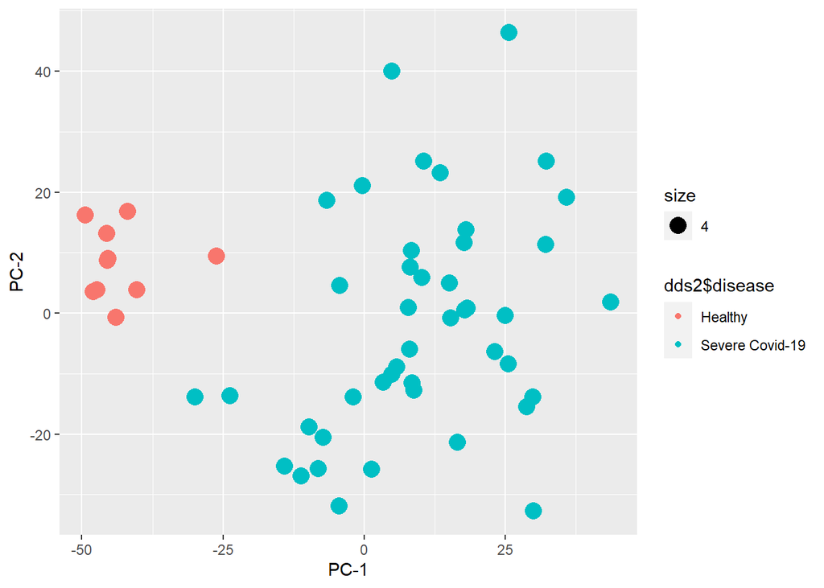

```r
dds2.symbol <- dds2
normcounts2 = assay(vst(dds2.symbol, blind=T))
var_per_gene2 <- apply(normcounts2, 1, var)  # Calculate the variance per gene
selectedGenes2 <- names(var_per_gene2[order(var_per_gene2, decreasing = T)][1:1000]) # Take the top 1000 variable genes
normcounts2.top1Kvar <- t(normcounts2[selectedGenes2,])
pcaResults2 = prcomp(normcounts2.top1Kvar)
qplot(pcaResults2$x[,1], pcaResults2$x[,2], col=dds2$disease, size=4) + labs(x="PC-1", y="PC-2")
```

We can notice the nice separation we get for both datasets regarding the disease factor.

### Limma analysis on HIV dataset - accession number GSE37250

```r
library("AnnotationDbi")
library(hrbrthemes) # ggplot2 themes
library(ReportingTools)
library(edgeR)
library(dplyr)
```

As our goal was to reproduce the experiment we mentioned at the beginning of this notebook, we analyzed teh HIV datasets using the same tool they used in the article. This tool is the “Limma” package.

Taken from the “BioConductor” guide: “Limma is a package for the analysis of gene expression data arising from microarray or RNA-seq technologies [32]. A core capability is the use of linear models to assess differential expression in the context of multi-factor designed experiments. Limma provides the ability to analyze comparisons between many RNA targets simultaneously. It has features that make the analyses stable even for experiments with small number of arrays—this is achieved by borrowing information across genes.”

- Loading the HIV counts data

```r
HIVcounts_init <- read.delim("GSE37250_non-normalized.txt.gz", row.names = 1)
head(HIVcounts_init)
```

```
##              SYMBOL X5483347021_A.AVG_Signal X5483347021_A.Detection.Pval
## ILMN_1762337    7A5                 143.5700                   0.36363640
## ILMN_2055271   A1BG                 220.6259                   0.01298701
## ILMN_1736007   A1BG                 125.7652                   0.57142860
## ILMN_2383229   A1CF                 114.5457                   0.68831170
## ILMN_1806310   A1CF                 147.8442                   0.31428570
## ILMN_1779670   A1CF                 134.6634                   0.47012990
##              X5483347021_B.AVG_Signal X5483347021_B.Detection.Pval
## ILMN_1762337                 132.6983                   0.46623380
## ILMN_2055271                 203.0341                   0.02467532
## ILMN_1736007                 165.4880                   0.14675330
## ILMN_2383229                 121.6644                   0.60779220
## ILMN_1806310                 158.0473                   0.19480520
## ILMN_1779670                 101.0619                   0.79350650
##              X5483347021_C.AVG_Signal X5483347021_C.Detection.Pval
## ILMN_1762337                 136.8932                   0.39220780
## ILMN_2055271                 222.3745                   0.01168831
## ILMN_1736007                 152.4443                   0.25584410
## ILMN_2383229                 142.8160                   0.33246750
## ILMN_1806310                 158.2308                   0.21818180
## ILMN_1779670                 130.4180                   0.46753250
##              X5483347021_D.AVG_Signal X5483347021_D.Detection.Pval
## ILMN_1762337                161.73730                   0.13116880
## ILMN_2055271                194.92990                   0.02337662
## ILMN_1736007                145.46670                   0.26233770
## ILMN_2383229                129.91080                   0.44025980
## ILMN_1806310                171.68250                   0.08051948
## ILMN_1779670                 96.28973                   0.81688310
##              X5483347021_E.AVG_Signal X5483347021_E.Detection.Pval
## ILMN_1762337                 138.4503                   0.41428570
## ILMN_2055271                 203.7914                   0.03376623
## ILMN_1736007                 155.0343                   0.25324680
## ILMN_2383229                 116.2044                   0.66493510
## ILMN_1806310                 148.4740                   0.31428570
## ILMN_1779670                 137.9700                   0.41688310
##              X5483347021_F.AVG_Signal X5483347021_F.Detection.Pval
## ILMN_1762337                 167.0903                   0.14805190
## ILMN_2055271                 182.9905                   0.07012987
## ILMN_1736007                 162.6656                   0.17402600
## ILMN_2383229                 155.6369                   0.21558440
```

[output cut: 3725 more lines]

```
## ILMN_1779670      A1CF         10
##                                                                                   DEFINITION
## ILMN_1762337                          Homo sapiens putative binding protein 7a5 (7A5), mRNA.
## ILMN_2055271                               Homo sapiens alpha-1-B glycoprotein (A1BG), mRNA.
## ILMN_1736007                               Homo sapiens alpha-1-B glycoprotein (A1BG), mRNA.
## ILMN_2383229 Homo sapiens APOBEC1 complementation factor (A1CF), transcript variant 2, mRNA.
## ILMN_1806310 Homo sapiens APOBEC1 complementation factor (A1CF), transcript variant 1, mRNA.
## ILMN_1779670 Homo sapiens APOBEC1 complementation factor (A1CF), transcript variant 3, mRNA.
##                                                                SYNONYMS
## ILMN_1762337
## ILMN_2055271                     A1B; GAB; HYST2477; ABG; DKFZp686F0970
## ILMN_1736007                     A1B; GAB; HYST2477; ABG; DKFZp686F0970
## ILMN_2383229 ASP; MGC163391; APOBEC1CF; ACF65; ACF64; ACF; RP11-564C4.2
## ILMN_1806310 ASP; APOBEC1CF; ACF65; ACF64; RP11-564C4.2; MGC163391; ACF
## ILMN_1779670                 ASP; ACF65; ACF64; RP11-564C4.2; MGC163391
```

We notice that some rows represent the same genes. This is due the fact we have different different probes (ids). The probe ID represents a unique oligonucleotide sequence that is used to hybridize to specific mRNA transcripts in the sample. e.g., the probe “ILMN_1705025” corresponds to a specific probe on the microarray chip, and it’s associated with a transcript

- Hence, we aggregate the genes by calculating the means over the corresponding rows for each sample (we could’ve also use the median).

```r
HIVcounts_init_agg <- HIVcounts_init %>%
  dplyr::select(-c(1:1)) %>%
  group_by(HIVcounts_init$SYMBOL) %>%
  summarise_all(mean)
head(HIVcounts_init_agg)
```

```
## # A tibble: 6 × 1,080
##   HIVcounts_in…¹ X5483…² X5483…³ X5483…⁴ X5483…⁵ X5483…⁶ X5483…⁷ X5483…⁸ X5483…⁹
##   <chr>            <dbl>   <dbl>   <dbl>   <dbl>   <dbl>   <dbl>   <dbl>   <dbl>
## 1 ""                236.   0.214    230.  0.192     237.   0.196    221.   0.210
## 2 "7A5"             144.   0.364    133.  0.466     137.   0.392    162.   0.131
## 3 "A1BG"            173.   0.292    184.  0.0857    187.   0.134    170.   0.143
## 4 "A1CF"            132.   0.491    127.  0.532     144.   0.339    133.   0.446
## 5 "A26C3"           130.   0.486    132.  0.440     144.   0.391    128.   0.411
## 6 "A2BP1"           121.   0.591    119.  0.617     117.   0.611    109.   0.668
## # … with 1,071 more variables: X5483347021_E.AVG_Signal <dbl>,
## #   X5483347021_E.Detection.Pval <dbl>, X5483347021_F.AVG_Signal <dbl>,
## #   X5483347021_F.Detection.Pval <dbl>, X5483347021_G.AVG_Signal <dbl>,
## #   X5483347021_G.Detection.Pval <dbl>, X5483347021_H.AVG_Signal <dbl>,
## #   X5483347021_H.Detection.Pval <dbl>, X5483347021_I.AVG_Signal <dbl>,
## #   X5483347021_I.Detection.Pval <dbl>, X5483347021_J.AVG_Signal <dbl>,
## #   X5483347021_J.Detection.Pval <dbl>, X5483347021_K.AVG_Signal <dbl>, …
```

- Fix back the symbol name col after the agg. (too long to run the chunk above so we patch it up)

```r
colnames(HIVcounts_init_agg)[colnames(HIVcounts_init_agg) == "HIVcounts_init$SYMBOL"] <- "SYMBOL"
```

- Rounding all the values to have solely integers.

```r
avg_signal_cols <- grep("AVG_Signal$", colnames(HIVcounts_init_agg))
HIVcounts <- cbind(SYMBOL = HIVcounts_init_agg$SYMBOL, HIVcounts_init_agg[, avg_signal_cols])
numeric_cols <- sapply(HIVcounts, is.numeric)
HIVcounts[numeric_cols] <- apply(HIVcounts[numeric_cols], 2, function(x) round(x))

current_names <- colnames(HIVcounts)
new_names <- sub(".AVG_Signal$", "", current_names)
colnames(HIVcounts) <- new_names


head(HIVcounts)
```

```
##   SYMBOL X5483347021_A X5483347021_B X5483347021_C X5483347021_D X5483347021_E
## 1                  236           230           237           221           211
## 2    7A5           144           133           137           162           138
## 3   A1BG           173           184           187           170           179
## 4   A1CF           132           127           144           133           134
## 5  A26C3           130           132           144           128           137
## 6  A2BP1           121           119           117           109           119
##   X5483347021_F X5483347021_G X5483347021_H X5483347021_I X5483347021_J
## 1           231           200           218           215           279
## 2           167           140           157           165           171
## 3           173           172           183           187           165
## 4           142           129           142           150           144
## 5           132           135           137           144           146
## 6           121           116           119           128           143
##   X5483347021_K X5483347021_L X5483347032_A X5483347032_B X5483347032_C
```

[output cut: 741 more lines]

```r
# Load the GSE series matrix file
gseHIV <- getGEO("GSE37250")
```

```
## Found 1 file(s)
```

```
## GSE37250_series_matrix.txt.gz
```

```r
# Extract the metadata from the GSE object
metadataHIV <- pData(gseHIV[[1]])

head(metadataHIV)
```

```
##                                                          title geo_accession
## GSM914353 active tuberculosis HIV negative Malawi WB_1_M_39619     GSM914353
## GSM914354 active tuberculosis HIV negative Malawi WB_1_M_39668     GSM914354
## GSM914355 active tuberculosis HIV negative Malawi WB_1_M_39827     GSM914355
## GSM914356 active tuberculosis HIV negative Malawi WB_1_M_39896     GSM914356
## GSM914357 active tuberculosis HIV negative Malawi WB_1_M_39956     GSM914357
## GSM914358 active tuberculosis HIV negative Malawi WB_1_M_39985     GSM914358
##                          status submission_date last_update_date type
## GSM914353 Public on Oct 23 2013     Apr 13 2012      Nov 30 2020  RNA
## GSM914354 Public on Oct 23 2013     Apr 13 2012      Nov 30 2020  RNA
## GSM914355 Public on Oct 23 2013     Apr 13 2012      Nov 30 2020  RNA
## GSM914356 Public on Oct 23 2013     Apr 13 2012      Nov 30 2020  RNA
## GSM914357 Public on Oct 23 2013     Apr 13 2012      Nov 30 2020  RNA
## GSM914358 Public on Oct 23 2013     Apr 13 2012      Nov 30 2020  RNA
##           channel_count                         source_name_ch1 organism_ch1
## GSM914353             1 Whole Blood from patient with Active TB Homo sapiens
## GSM914354             1 Whole Blood from patient with Active TB Homo sapiens
## GSM914355             1 Whole Blood from patient with Active TB Homo sapiens
## GSM914356             1 Whole Blood from patient with Active TB Homo sapiens
## GSM914357             1 Whole Blood from patient with Active TB Homo sapiens
## GSM914358             1 Whole Blood from patient with Active TB Homo sapiens
##                          characteristics_ch1    characteristics_ch1.1
## GSM914353 disease state: active tuberculosis hiv status: HIV negative
## GSM914354 disease state: active tuberculosis hiv status: HIV negative
## GSM914355 disease state: active tuberculosis hiv status: HIV negative
## GSM914356 disease state: active tuberculosis hiv status: HIV negative
## GSM914357 disease state: active tuberculosis hiv status: HIV negative
## GSM914358 disease state: active tuberculosis hiv status: HIV negative
##                 characteristics_ch1.2 characteristics_ch1.3 molecule_ch1
## GSM914353 geographical region: Malawi   tissue: whole blood    total RNA
## GSM914354 geographical region: Malawi   tissue: whole blood    total RNA
## GSM914355 geographical region: Malawi   tissue: whole blood    total RNA
## GSM914356 geographical region: Malawi   tissue: whole blood    total RNA
## GSM914357 geographical region: Malawi   tissue: whole blood    total RNA
## GSM914358 geographical region: Malawi   tissue: whole blood    total RNA
##                                                    extract_protocol_ch1
## GSM914353 Standard PAXgene® blood RNA extraction kit protocol (Qiagen).
## GSM914354 Standard PAXgene® blood RNA extraction kit protocol (Qiagen).
## GSM914355 Standard PAXgene® blood RNA extraction kit protocol (Qiagen).
## GSM914356 Standard PAXgene® blood RNA extraction kit protocol (Qiagen).
```

[output cut: 64 more lines]

```
## GSM914358               NONE          47323 Reanalyzed by: GSE162330
##             disease state:ch1 geographical region:ch1 hiv status:ch1
## GSM914353 active tuberculosis                  Malawi   HIV negative
## GSM914354 active tuberculosis                  Malawi   HIV negative
## GSM914355 active tuberculosis                  Malawi   HIV negative
## GSM914356 active tuberculosis                  Malawi   HIV negative
## GSM914357 active tuberculosis                  Malawi   HIV negative
## GSM914358 active tuberculosis                  Malawi   HIV negative
##            tissue:ch1
## GSM914353 whole blood
## GSM914354 whole blood
## GSM914355 whole blood
## GSM914356 whole blood
## GSM914357 whole blood
## GSM914358 whole blood
```

- Create DGEList object

```r
d0 <- DGEList(HIVcounts[-1])
```

- Calculate normalization factors

```r
d0 <- calcNormFactors(d0)
head(d0)
```

```
## An object of class "DGEList"
## $counts
##   X5483347021_A X5483347021_B X5483347021_C X5483347021_D X5483347021_E
## 1           236           230           237           221           211
## 2           144           133           137           162           138
## 3           173           184           187           170           179
## 4           132           127           144           133           134
## 5           130           132           144           128           137
## 6           121           119           117           109           119
##   X5483347021_F X5483347021_G X5483347021_H X5483347021_I X5483347021_J
## 1           231           200           218           215           279
## 2           167           140           157           165           171
## 3           173           172           183           187           165
## 4           142           129           142           150           144
## 5           132           135           137           144           146
```

[output cut: 752 more lines]

- Now we’ll filter out genes that has a count lower than cutoff = 1

```r
cutoff <- 1
drop <- which(apply(cpm(d0), 1, max) < cutoff)
d <- d0

if (length(drop) != 0) {
  d <- d0[-drop,]

}

dim(d) # number of genes left
```

```
## [1] 31405   537
```

- Removing prefix from samples to fit metadata as seen in ncbi

```r
colnames(HIVcounts) <- substr(colnames(HIVcounts), 2, nchar(colnames(HIVcounts)))
```

- Small fix to some bug we had in the cols naming (takes a lot of time to run the chunk above, so we’re not taking chances by re-running it - so we patch it up)

```r
colnames(HIVcounts)[colnames(HIVcounts) == "YMBOL"] <- "SYMBOL"
rownames(HIVcounts) <- HIVcounts$SYMBOL
head(HIVcounts)
```

```
##       SYMBOL 5483347021_A 5483347021_B 5483347021_C 5483347021_D 5483347021_E
##                       236          230          237          221          211
## 7A5      7A5          144          133          137          162          138
## A1BG    A1BG          173          184          187          170          179
## A1CF    A1CF          132          127          144          133          134
## A26C3  A26C3          130          132          144          128          137
## A2BP1  A2BP1          121          119          117          109          119
##       5483347021_F 5483347021_G 5483347021_H 5483347021_I 5483347021_J
##                231          200          218          215          279
## 7A5            167          140          157          165          171
## A1BG           173          172          183          187          165
## A1CF           142          129          142          150          144
## A26C3          132          135          137          144          146
## A2BP1          121          116          119          128          143
##       5483347021_K 5483347021_L 5483347032_A 5483347032_B 5483347032_C
##                203          213          191          205          256
## 7A5            128          150          127          131          124
## A1BG           167          168          152          147          161
## A1CF           125          137          126          121          130
## A26C3          140          129          101          124          116
## A2BP1          122          122          103           99          110
##       5483347032_D 5483347032_E 5483347032_F 5483347032_G 5483347032_H
##                185          199          223          227          207
## 7A5            130          112          109          121          130
## A1BG           149          145          136          146          132
## A1CF           131          122          121          119          113
## A26C3          123          124          120          126          116
## A2BP1          116          115           99          101           98
##       5483347032_I 5483347032_J 5483347032_K 5483347032_L 5483347074_A
##                233          219          202          203          197
## 7A5            126          125          100          115          111
## A1BG           169          145          159          128          148
## A1CF           137          123          125          123          108
## A26C3          124          121          124          106          115
## A2BP1          105          107          101           99          113
##       5483347074_B 5483347074_C 5483347074_D 5483347074_E 5483347074_F
##                178          244          208          192          222
## 7A5            106          120          110          124          125
## A1BG           141          148          152          150          138
## A1CF           121          124          119          119          123
```

[output cut: 701 more lines]

```
## A2BP1          110          101          137           89          106
##       5685521033_F 5685521033_G 5685521033_H 5685521033_I 5685521033_J
##                193          173          199          204          262
## 7A5            143          144          130          132          120
## A1BG           140          161          140          125          143
## A1CF           127          127          120          126          119
## A26C3          124          122          112          120          113
## A2BP1          104          110          104          114          100
##       5685521033_K 5685521033_L
##                156          187
## 7A5            106          121
## A1BG           138          151
## A1CF           116          107
## A26C3          111          119
## A2BP1           94           92
```

- Set disease state as a factor

```r
# Erase HIV prefix
metadataHIV$`hiv status:ch1` <- sub("HIV ", "", metadataHIV$`hiv status:ch1`)

# setting as factor
class(metadataHIV$`hiv status:ch1`)
```

```
## [1] "character"
```

```r
metadataHIV <- mutate(metadataHIV, `hiv status:ch1` = as.factor(`hiv status:ch1`))
class(metadataHIV$`hiv status:ch1`)
```

```
## [1] "factor"
```

```r
head(metadataHIV$`hiv status:ch1`)
```

```
## [1] negative negative negative negative negative negative
## Levels: negative positive
```

- Setting ‘group’ similarly as was done with ‘design’ in DESeq2

```r
cultivar <- metadataHIV$`hiv status:ch1`
group <- interaction(cultivar)
```

- Specifying the model to be fitted. We do this before using voom since voom uses variances of the model residuals (observed - fitted)

```r
mm <- model.matrix(~0 + group)
```

- The above specifies a model where each coefficient corresponds to a group mean Voom

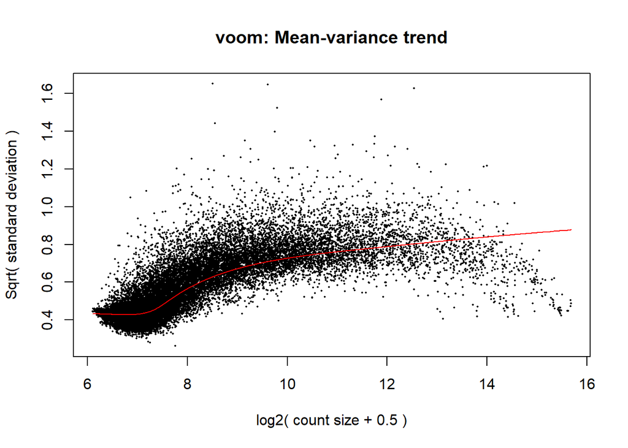

```r
y <- voom(d, mm, plot = T)
```

- What is voom doing?

Counts are transformed to log2 counts per million reads (CPM), where “per million reads” is defined based on the normalization factors we calculated earlier A linear model is fitted to the log2 CPM for each gene, and the residuals are calculated A smoothed curve is fitted to the sqrt(residual standard deviation) by average expression (see red line in plot above) The smoothed curve is used to obtain weights for each gene and sample that are passed into limma along with the log2 CPMs. More details at https://genomebiology.biomedcentral.com/articles/10.1186/gb-2014-15-2-r29

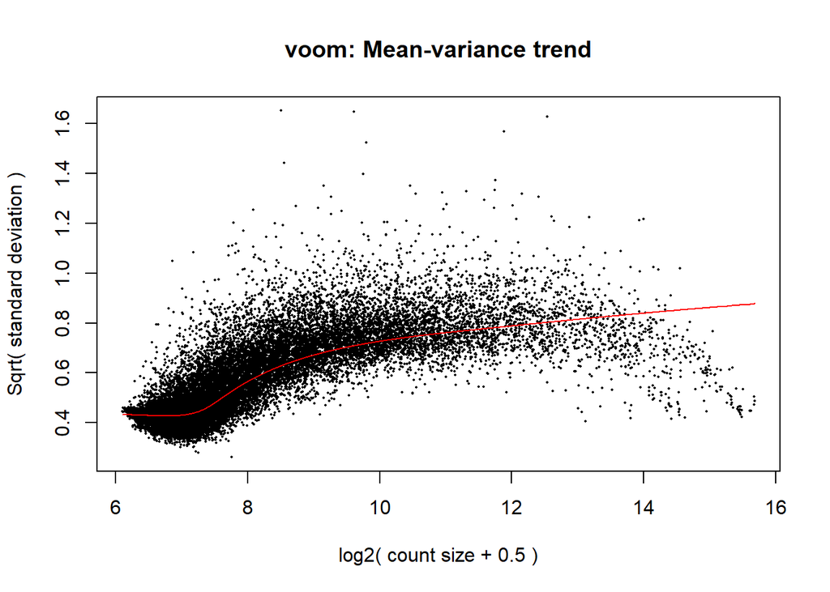

```r
tmp <- voom(d0, mm, plot = T)
```

- lmFit fits a linear model using weighted least squares for each gene:

```r
fit <- lmFit(y, mm)
# naming the coefs with the fitting symbols
rownames(fit@.Data[[1]]) <- HIVcounts$SYMBOL
head(coef(fit))
```

```
##       groupnegative grouppositive
##            3.225766      3.217973
## 7A5        2.557712      2.596191
## A1BG       2.762782      2.770654
## A1CF       2.513358      2.522988
## A26C3      2.487414      2.540651
## A2BP1      2.212288      2.218779
```

- Comparisons between groups (log fold-changes) are obtained as contrasts of these fitted linear models:

```r
contr <- makeContrasts(groupnegative - grouppositive, levels = colnames(coef(fit)))
head(contr)
```

```
##                Contrasts
## Levels          groupnegative - grouppositive
##   groupnegative                             1
##   grouppositive                            -1
```

- Estimate contrast for each gene

```r
tmp <- contrasts.fit(fit, contr)
```

- Empirical Bayes smoothing of standard errors (shrinks standard errors that are much larger or smaller than those from other genes towards the average standard error) (see https://www.degruyter.com/doi/10.2202/1544-6115.1027)

```r
tmp <- eBayes(tmp)
```

- What genes are most differentially expressed?

```r
top.table <- topTable(tmp, sort.by = "P", n = Inf)
head(top.table, 20)
```

```
##                 logFC  AveExpr         t      P.Value    adj.P.Val        B
## EYS         0.1337695 3.521740  8.546155 1.291126e-16 4.054783e-12 26.79996
## NCRNA00200  0.1671963 3.742488  8.224691 1.451397e-15 1.775481e-11 24.34995
## LMAN1       0.1653021 4.273000  8.203673 1.696049e-15 1.775481e-11 23.82540
## ANKRD40     0.1665787 4.279863  8.070903 4.506037e-15 3.537802e-11 22.91792
## CAPS2       0.1048543 3.460129  7.855341 2.145597e-14 1.123888e-10 21.97514
## XPA         0.1279531 3.876013  7.855235 2.147216e-14 1.123888e-10 21.73025
## ASS1        0.1232905 3.713962  7.702018 6.383311e-14 2.863827e-10 20.80461
## MIR129-2    0.1708070 3.629864  7.548492 1.870409e-13 7.225349e-10 19.83540
## MET         0.1606151 4.251912  7.533844 2.070630e-13 7.225349e-10 19.39954
## AACSL       0.1409471 3.341995  7.466000 3.309660e-13 1.039399e-09 19.41689
## JAGN1       0.1564193 4.392383  7.303787 1.002133e-12 2.861090e-09 17.87407
## NUS1        0.1783840 3.650897  7.263601 1.314739e-12 3.440780e-09 17.98545
## LOC730176   0.1306672 3.616708  7.247978 1.460629e-12 3.528543e-09 17.90145
## LOC650717   0.1476716 3.270423  7.235673 1.586652e-12 3.559200e-09 17.93896
## ERCC-00126  0.1335619 2.942145  7.209347 1.893268e-12 3.963873e-09 17.78832
## CLCA1      -0.1125348 2.635230 -7.153419 2.751012e-12 5.399721e-09 17.38739
## RNF180      0.1504630 2.977064  7.115241 3.545619e-12 6.230294e-09 17.18572
## LOC654161   0.2209726 4.766716  7.114168 3.570938e-12 6.230294e-09 16.54211
## OR9A4       0.1447460 3.821616  7.094035 4.080392e-12 6.744459e-09 16.84602
## INSM1       0.1909087 3.371479  7.034008 6.061938e-12 9.518758e-09 16.63650
```

- How many DE genes are there?

```r
length(which(top.table$adj.P.Val < 0.05))
```

```
## [1] 7268
```

- Filtering non-significant genes

```r
## Filter non-significant genes from first set
filter.sgn.genes.hiv <- as_tibble(top.table)
filter.sgn.genes.hiv$symbol <- rownames(top.table)
filter.sgn.genes.hiv <- filter(filter.sgn.genes.hiv, adj.P.Val < 0.05)
head(filter.sgn.genes.hiv)
```

```
## # A tibble: 6 × 7
##   logFC AveExpr     t  P.Value adj.P.Val     B symbol
##   <dbl>   <dbl> <dbl>    <dbl>     <dbl> <dbl> <chr>
## 1 0.134    3.52  8.55 1.29e-16  4.05e-12  26.8 EYS
## 2 0.167    3.74  8.22 1.45e-15  1.78e-11  24.3 NCRNA00200
## 3 0.165    4.27  8.20 1.70e-15  1.78e-11  23.8 LMAN1
## 4 0.167    4.28  8.07 4.51e-15  3.54e-11  22.9 ANKRD40
## 5 0.105    3.46  7.86 2.15e-14  1.12e-10  22.0 CAPS2
## 6 0.128    3.88  7.86 2.15e-14  1.12e-10  21.7 XPA
```

### INTERSECT COMMON DEGs from COVID-19 datasets and HIV

```r
filter.intersect.covid.hiv <- filter.intersect.covid[filter.intersect.covid$symbol %in% filter.sgn.genes.hiv$symbol,]
rownames(filter.intersect.covid.hiv) <- filter.intersect.covid.hiv$symbol

attributes(filter.intersect.covid.hiv)$row.names <- NULL
row.names(filter.intersect.covid.hiv) <- filter.intersect.covid.hiv$symbol

head(filter.intersect.covid.hiv)
```

```
## log2 fold change (MAP): disease Healthy vs COVID.19
## Wald test p-value: disease Healthy vs COVID.19
## DataFrame with 6 rows and 6 columns
##         baseMean log2FoldChange     lfcSE      pvalue        padj      symbol
##        <numeric>      <numeric> <numeric>   <numeric>   <numeric> <character>
## PLK1    189.7097       -3.85383  0.222130 1.37961e-68 2.26766e-64        PLK1
## RRM2    865.6643       -3.79574  0.223258 5.29987e-66 4.35570e-62        RRM2
## FOXM1    91.7940       -3.05689  0.189140 7.32139e-60 3.00854e-56       FOXM1
## MKI67   571.1731       -3.13102  0.209622 1.25338e-51 2.94311e-48       MKI67
## RAD54L   37.4322       -2.83138  0.233844 7.46729e-35 4.09133e-32      RAD54L
## BUB1B    71.3315       -2.74685  0.228961 2.45696e-34 1.28207e-31       BUB1B
```

- Visualizing Venn diagram for common DEGs

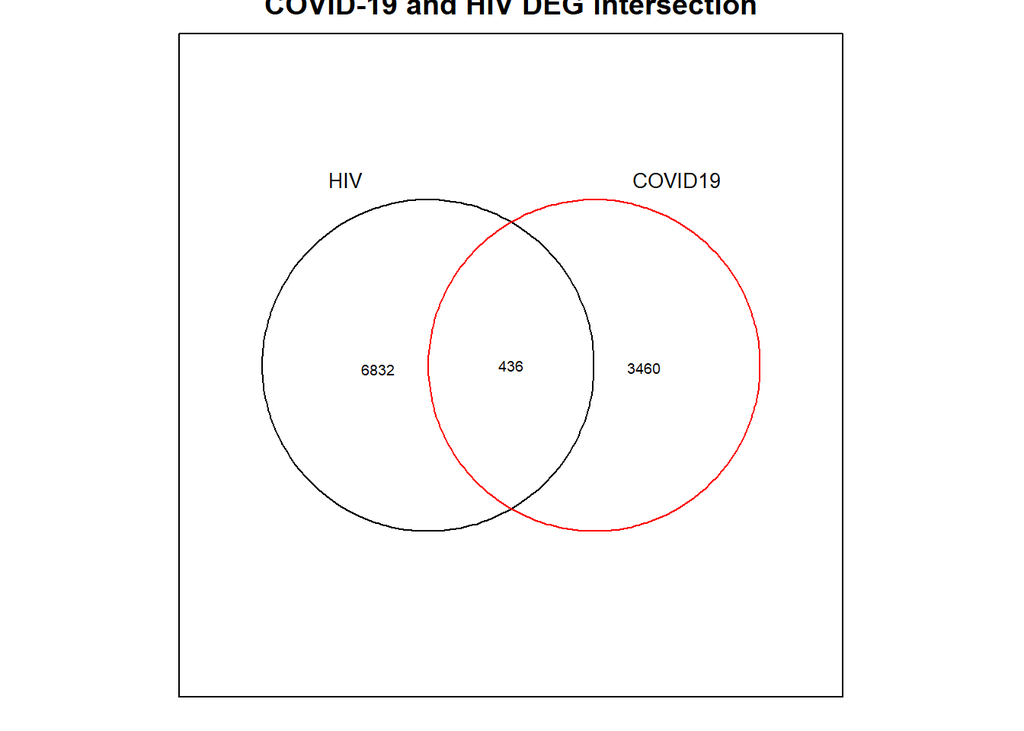

```r
# Install and load the venn package
library(venn)

# Create a Venn diagram with filled circles
venn(list(HIV = filter.sgn.genes.hiv$symbol, COVID19 = filter.intersect.covid$symbol), main = "COVID-19 and HIV DEG intersection",
     col = c("black", "red", "black"), fill = c("blue", "pink", "green"))
```

### GSEA

We’ll use functional enrichment analysis with the Hallmark pathways gene sets.

- First we need to create an ordered vector by the log fold change with the gene symbols as names:

```r
sorted_row_names <- row.names(filter.intersect.covid.hiv)[order(-filter.intersect.covid.hiv$log2FoldChange)]
filter.intersect.covid.hiv_sorted <- filter.intersect.covid.hiv[sorted_row_names, ]

# Create a named vector of genes_ordered with new row names
genes_ordered <- setNames(filter.intersect.covid.hiv_sorted$log2FoldChange, row.names(filter.intersect.covid.hiv_sorted))
```

- For the hallmarks pathways gene sets we’ll use msigdbr package.

```r
library(msigdbr)
hallmarks <- msigdbr(species = "Homo sapiens", category = "H") %>%
  dplyr::select(gs_name, gene_symbol)
```

- Using GSEA() as done in class

```r
library(clusterProfiler)
hm <- GSEA(genes_ordered, TERM2GENE = hallmarks)
```

```
## preparing geneSet collections...
```

```
## GSEA analysis...
```

```
## leading edge analysis...
```

```
## done...
```

- Visualizing the results

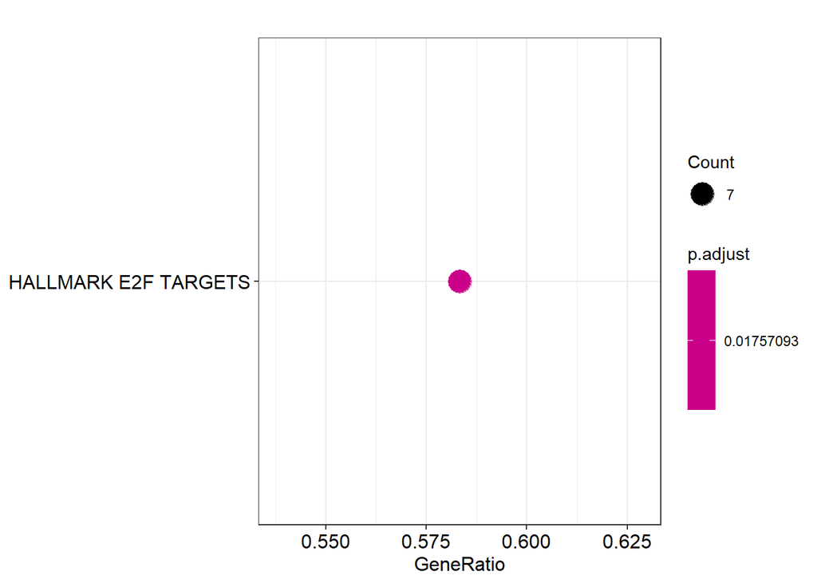

```r
hallmarks <- msigdbr(species = "Homo sapiens", category = "H")
hallmarks <- hallmarks[,c('gs_name', 'gene_symbol')]
dotplot(hm)
```

Unlike HW2, we got here just one Hallmark. As we interpret the GSEA results, we understand that we might have diverged from the experiment which was made in the article (due to several optional reasons such as different pre-processing decisions / aggregating methods / different computation of COMMON DEGs or computation of DEGs for COVID/HIV albeit using the same tools)

Nonetheless, the sole hallmark we received fits the findings of the article, as we got E2F Targets hallmark which plays a crucial role in the control of cell cycle progression, DNA replication, and cell proliferation.

In addition, though this kind of result might indicate on a troublesome analysis it’s not uncommon to get one hallmark for such a small number of genes (436).

### Survival analysis with xCell

# Preparing and running xCell

Now we are focusing on the survival rates, while considering the differences in the design in our groups of interest.

The xCell tool can help us distinct between the groups by composition and properties of cell types, using the DEGs. This will lead to a more precise result, and serve as additional evidence to our hypothesis.

```r
library(survival)
library(survminer)
library(xCell)
```

- Load COVID-19 gene expression data - in a table (not csv file)

```r
counts_surv <- read_table("GSE152418_p20047_Study1_RawCounts.txt.gz")
counts_surv$S145_nCOV001_C <- NULL # removing the convalescent patient from the dataframe
head(counts_surv)
```

```
## # A tibble: 6 × 34
##   ENSEMBLID      S147_…¹ S149_…² S150_…³ S151_…⁴ S152_…⁵ S153_…⁶ S154_…⁷ S155_…⁸
##   <chr>            <dbl>   <dbl>   <dbl>   <dbl>   <dbl>   <dbl>   <dbl>   <dbl>
## 1 ENSG000002239…       0       0       0       0       0       0       0       2
## 2 ENSG000002272…       0       3      16       1       2      18       6      20
## 3 ENSG000002782…       1       2       0       3       0       0       1       3
## 4 ENSG000002434…       0       0       1       0       0       0       0       0
## 5 ENSG000002843…       0       0       0       0       0       0       0       0
## 6 ENSG000002376…       0       0       0       0       0       0       0       0
## # … with 25 more variables: `S156_nCOV024EUHM-Draw-1` <dbl>,
## #   S157_nCOV0029EUHM <dbl>, `S175_nCoV024EUHM-Draw-2` <dbl>,
## #   `S176_nCoV025EUHM-Draw-1` <dbl>, `S177_nCoV025EUHM-Draw-2` <dbl>,
## #   `S178_nCoV028EUHM-Draw-1` <dbl>, `S179_nCoV033EUHM-Draw-1` <dbl>,
## #   `S180_nCoV034EUHM-Draw-1` <dbl>, S061_257 <dbl>, S062_258 <dbl>,
## #   S063_259 <dbl>, S064_260 <dbl>, S065_261 <dbl>, S066_265 <dbl>,
## #   S067_270 <dbl>, S068_272 <dbl>, S069_273 <dbl>, S070_279 <dbl>, …
```

- We’ll now process the data-frame to fit xCell’s format - converting ENSEMBLID to SYMBOL in all genes and creating an appropriate header:

```r
library(biomaRt)

# connect to the Ensembl database using the biomaRt package
ensembl <- useMart("ensembl")

# define the dataset and attributes to retrieve
attributes <- c("ensembl_gene_id", "external_gene_name")
ensembl <- useDataset("hsapiens_gene_ensembl", ensembl)

# get a list of all ENSEMBLIDs in your dataframe
ensemblids <- unique(counts_surv$ENSEMBLID)

# query the biomaRt database to get the gene symbols for each ENSEMBLID
results <- getBM(attributes = attributes,
                 filters = "ensembl_gene_id",
                 values = ensemblids,
                 mart = ensembl)

# merge the results back into your original dataframe
counts_surv <- merge(counts_surv, results, by.x = "ENSEMBLID", by.y = "ensembl_gene_id", all.x = TRUE)
counts_surv <- counts_surv[, c(ncol(counts_surv), 2:(ncol(counts_surv)-1))]
colnames(counts_surv)[colnames(counts_surv) == "external_gene_name"] <- "SYMBOL"
counts_surv <- subset(counts_surv, SYMBOL != "")

# uniting rows that were mapped to same gene and summing their counts
counts_surv <- aggregate(. ~ SYMBOL, data = counts_surv, FUN = sum)

write.csv(counts_surv, "counts_surv.csv", row.names = FALSE)

head(counts_surv)
```

```
##      SYMBOL S147_nCoV001EUHM-Draw-1 S149_nCoV002EUHM-Draw-2
## 1 5_8S_rRNA                       1                       0
## 2   5S_rRNA                       5                       6
## 3       7SK                       0                       0
## 4      A1BG                       6                       4
## 5  A1BG-AS1                      35                      29
## 6      A1CF                       2                       1
##   S150_nCoV003EUHM-Draw-1 S151_nCoV004EUHM-Draw-1 S152_nCoV006EUHM-Draw-1
## 1                       0                       0                       1
## 2                       8                       0                       6
## 3                       0                       0                       2
## 4                       3                       6                       2
## 5                      36                      29                      30
## 6                       0                       0                       0
##   S153_nCoV007EUHM-Draw-1 S154_nCoV0010EUHM-Draw-1 S155_nCOV021EUHM
```

[output cut: 41 more lines]

- Load COVID-19 gene expression data (csv format, as seen in class)

```r
counts_surv <- read.csv("counts_surv.csv", header=TRUE, row.names=1, as.is=TRUE)
head(counts_surv)
```

```
##           S147_nCoV001EUHM.Draw.1 S149_nCoV002EUHM.Draw.2
## 5_8S_rRNA                       1                       0
## 5S_rRNA                         5                       6
## 7SK                             0                       0
## A1BG                            6                       4
## A1BG-AS1                       35                      29
## A1CF                            2                       1
##           S150_nCoV003EUHM.Draw.1 S151_nCoV004EUHM.Draw.1
## 5_8S_rRNA                       0                       0
## 5S_rRNA                         8                       0
## 7SK                             0                       0
## A1BG                            3                       6
## A1BG-AS1                       36                      29
## A1CF                            0                       0
##           S152_nCoV006EUHM.Draw.1 S153_nCoV007EUHM.Draw.1
## 5_8S_rRNA                       1                       0
## 5S_rRNA                         6                       2
## 7SK                             2                       0
## A1BG                            2                       1
## A1BG-AS1                       30                      38
## A1CF                            0                       0
##           S154_nCoV0010EUHM.Draw.1 S155_nCOV021EUHM S156_nCOV024EUHM.Draw.1
## 5_8S_rRNA                        0                4                       0
## 5S_rRNA                          6                5                       7
## 7SK                              0                0                       0
## A1BG                             5               13                       7
## A1BG-AS1                        37               34                      42
## A1CF                             6                4                       0
##           S157_nCOV0029EUHM S175_nCoV024EUHM.Draw.2 S176_nCoV025EUHM.Draw.1
## 5_8S_rRNA                 2                       0                       0
## 5S_rRNA                   8                       4                       7
## 7SK                       1                       0                       0
## A1BG                      4                       2                       2
## A1BG-AS1                 56                      27                      35
## A1CF                      4                       2                       0
##           S177_nCoV025EUHM.Draw.2 S178_nCoV028EUHM.Draw.1
## 5_8S_rRNA                       0                       3
## 5S_rRNA                         4                       2
## 7SK                             2                       0
## A1BG                            2                       4
```

[output cut: 15 more lines]

```
## A1CF             0        1        0        0        0        0        0
##           S070_279 S071_280 S181_255 S182_SHXA10 S183_263 S184_SHXA18 S185_266
## 5_8S_rRNA        0        0        0           0        0           0        0
## 5S_rRNA          6        6        5           1        5           6        2
## 7SK              1        1        0           0        1           0        1
## A1BG             1        5        5           3        3           4        0
## A1BG-AS1        63       54       20          39       43          71       34
## A1CF             0        1        1           2        0           1        0
##           S186_SHXA14
## 5_8S_rRNA           0
## 5S_rRNA             0
## 7SK                 0
## A1BG                8
## A1BG-AS1           43
## A1CF                2
```

- Run xCell

```r
counts.xCell <- xCellAnalysis(counts_surv)
```

```
## [1] "Num. of genes: 10483"
```

```
## Setting parallel calculations through a MulticoreParam back-end
## with workers=4 and tasks=100.
## Estimating ssGSEA scores for 489 gene sets.
## [1] "Calculating ranks..."
## [1] "Calculating absolute values from ranks..."
##
```

- Plot the results with heatmap

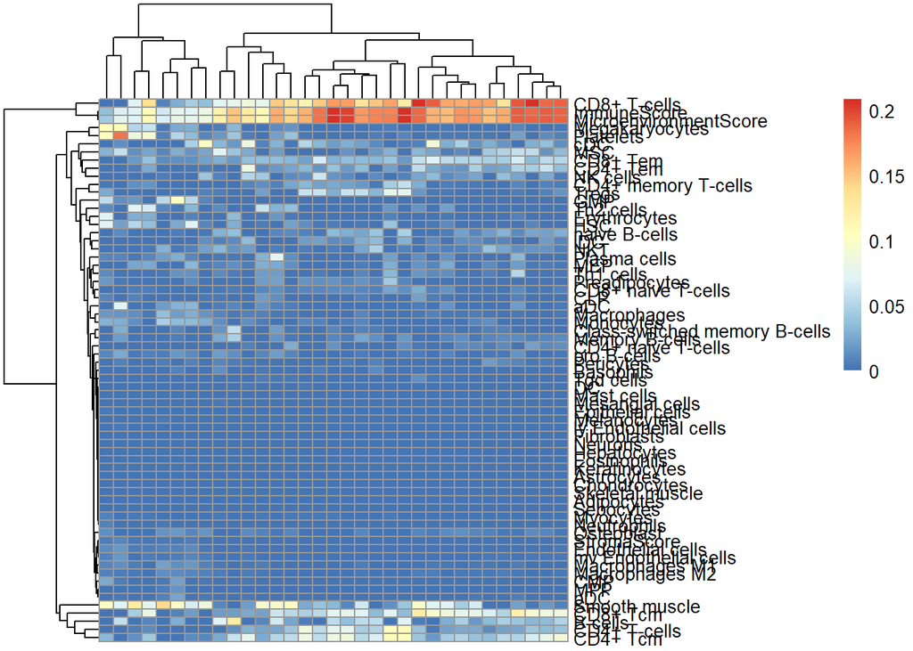

```r
library(pheatmap)
pheatmap(counts.xCell, show_colnames = F)
```

It’s difficult to see clear clusters because some enrichment score are extremely high

- We’ll perform similar operations on the data for better visualization as was seen in the tutorial:

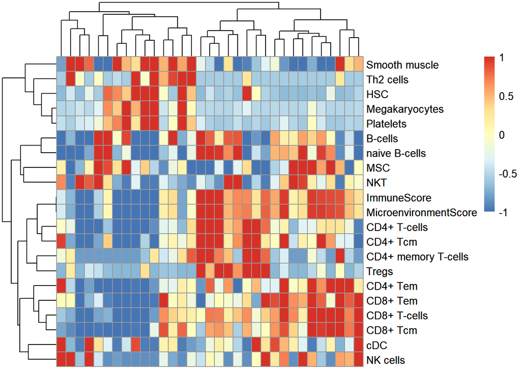

```r
counts.xCell.filtered <- counts.xCell[rowMeans(counts.xCell) > 0.01,]
counts.xCell.filtered.scaled <- t(scale(t(counts.xCell.filtered)))
counts.xCell.filtered.scaled[counts.xCell.filtered.scaled>1] <- 1
counts.xCell.filtered.scaled[counts.xCell.filtered.scaled< -1] <- -1
p <- pheatmap(counts.xCell.filtered.scaled, show_colnames = F)
p
```

- Let’s cut the column’s dendrogram into four clusters

```r
myclusters <- cutree(p$tree_col, k=4)
names(myclusters) == names(counts.xCell["ImmuneScore",])
```

```
##  [1] TRUE TRUE TRUE TRUE TRUE TRUE TRUE TRUE TRUE TRUE TRUE TRUE TRUE TRUE TRUE
## [16] TRUE TRUE TRUE TRUE TRUE TRUE TRUE TRUE TRUE TRUE TRUE TRUE TRUE TRUE TRUE
## [31] TRUE TRUE TRUE
```

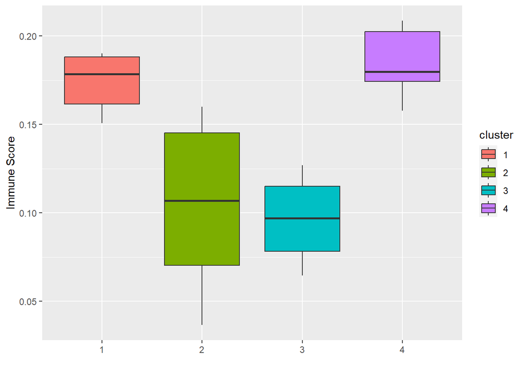

```r
MEscore.df <- data.frame("score" = counts.xCell["ImmuneScore",],
                         "cluster" = factor(myclusters),
                         row.names = names(myclusters))

ggplot(MEscore.df, aes(x=cluster, y=score, fill=cluster)) +
  geom_boxplot() +
  labs(x="", y="Immune Score")
```

```r
# loading our data and selecting the relevant columns
gse_surv <- getGEO(filename="GSE152418_series_matrix.txt")
```

```
## Using locally cached version of GPL24676 found here:
## C:\Users\Ofer\AppData\Local\Temp\RtmpWk9mrT/GPL24676.soft.gz
```

```r
metadata_surv <- as_tibble(gse_surv)
metadata_surv <- metadata_surv %>%
  dplyr::select(sample = title, disease = disease.state.ch1, sex = gender.ch1, status = severity.ch1, time = characteristics_ch1)

# converting severety, sex and time features from string to numeric (double)
metadata_surv$sex <- gsub("M", "1", metadata_surv$sex)
metadata_surv$sex <- as.numeric(gsub("F", "2", metadata_surv$sex))
metadata_surv$time <- as.numeric(gsub("days_post_symptom_onset: ", "", metadata_surv$time))
metadata_surv$time <- ifelse(is.na(metadata_surv$time), 42, metadata_surv$time)
metadata_surv$status <- gsub("Healthy", "1", metadata_surv$status)
metadata_surv$status <- gsub("Moderate", "1", metadata_surv$status)
metadata_surv$status <- gsub("Severe", "2", metadata_surv$status)
metadata_surv$status <- as.numeric(gsub("ICU", "2", metadata_surv$status))
metadata_surv <- metadata_surv %>%
  filter(disease != "Convalescent")

write.csv(metadata_surv, "metadata.csv", row.names = FALSE)
```

# Using xCell’s results for survival analysis

- Load COVID-19 survival metadata and plot KM curve

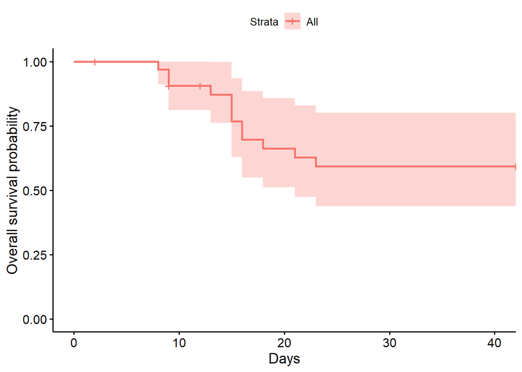

```r
# here we are importing the metadata in a csv format which is more convenient
# this is the metadata of the first COVID-19 dataset
Data <- read.csv("metadata.csv", header=TRUE)
ggsurvplot(
  fit = survfit(Surv(time, status) ~ 1, data = Data),
  xlab = "Days",
  ylab = "Overall survival probability")
```

- Compare KM-curves of 2 (second and third) clusters

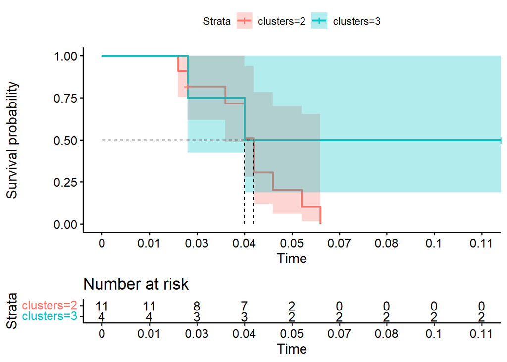

```r
Data$clusters <- MEscore.df$cluster

Data.2.vs.3 <- Data[Data$cluster %in% c(2,3),]

fit <- survfit(Surv(time, status) ~ clusters, data = Data.2.vs.3)
ggsurvplot(fit, surv.median.line = "hv", xlim=c(0,40), risk.table = TRUE, xscale = "d_y", break.x.by = 5, conf.int = T)
```

- Run Log-rank test

```r
survdiff(Surv(time, status) ~ clusters, data = Data.2.vs.3)
```

```
## Call:
## survdiff(formula = Surv(time, status) ~ clusters, data = Data.2.vs.3)
##
##             N Observed Expected (O-E)^2/E (O-E)^2/V
## clusters=2 11       10     7.85     0.588         2
## clusters=3  4        2     4.15     1.113         2
##
##  Chisq= 2  on 1 degrees of freedom, p= 0.2
```